# Analysis using Multiple Imputation (scmfcs)

## Pooled Anova Results

Using mi.anova()

- Uses D2 test

```r
anova_mod3 %>%
  knitr::kable(digits = c(2, 2, 2, 2, 3, 3, 3))
```

| x |
| --- |
| 0.18 |

|  | SSQ | df1 | df2 | F value | Pr(>F) | eta2 | partial.eta2 |
| --- | --- | --- | --- | --- | --- | --- | --- |
| framing_condition | 4.45 | 2 | 277911.15 | 1.94 | 0.144 | 0.003 | 0.004 |
| norm_condition | 6.52 | 4 | 71957.17 | 1.41 | 0.227 | 0.005 | 0.005 |
| biospheric_center | 69.70 | 1 | 182541.21 | 60.76 | 0.000 | 0.048 | 0.056 |
| altruistic_center | 1.79 | 1 | 4948.63 | 1.48 | 0.224 | 0.001 | 0.002 |
| egoistic_center | 55.16 | 1 | 117647.58 | 48.03 | 0.000 | 0.038 | 0.044 |
| hedonic_center | 3.39 | 1 | 10965.18 | 2.88 | 0.090 | 0.002 | 0.003 |
| ingroup_center | 0.80 | 1 | 15534.19 | 0.67 | 0.413 | 0.001 | 0.001 |
| self_dec_center | 7.50 | 1 | 10820.41 | 6.41 | 0.011 | 0.005 | 0.006 |
| impress_manag_center | 0.15 | 1 | 48583.18 | 0.12 | 0.732 | 0.000 | 0.000 |
| clothing_center | 0.01 | 1 | 3781093.85 | 0.01 | 0.942 | 0.000 | 0.000 |
| Gender | 4.35 | 1 | 2572.87 | 3.60 | 0.058 | 0.003 | 0.004 |
| Age_center | 5.96 | 1 | 71.04 | 3.63 | 0.061 | 0.004 | 0.005 |
| framing_condition:norm_condition | 5.70 | 8 | 55071.52 | 0.61 | 0.767 | 0.004 | 0.005 |
| framing_condition:biospheric_center | 0.74 | 2 | 3277.29 | 0.27 | 0.761 | 0.001 | 0.001 |
| norm_condition:biospheric_center | 11.75 | 4 | 97395.31 | 2.56 | 0.037 | 0.008 | 0.010 |
| framing_condition:altruistic_center | 1.29 | 2 | 6519.70 | 0.52 | 0.592 | 0.001 | 0.001 |
| norm_condition:altruistic_center | 9.15 | 4 | 9084.58 | 1.96 | 0.098 | 0.006 | 0.008 |
| framing_condition:egoistic_center | 0.48 | 2 | 15139.30 | 0.19 | 0.831 | 0.000 | 0.000 |
| norm_condition:egoistic_center | 2.16 | 4 | 8536.54 | 0.44 | 0.776 | 0.001 | 0.002 |
| framing_condition:hedonic_center | 2.18 | 2 | 21454.97 | 0.93 | 0.396 | 0.002 | 0.002 |
| norm_condition:hedonic_center | 8.19 | 4 | 22945.86 | 1.76 | 0.133 | 0.006 | 0.007 |
| framing_condition:ingroup_center | 0.88 | 2 | 493256.84 | 0.38 | 0.685 | 0.001 | 0.001 |
| norm_condition:ingroup_center | 1.08 | 4 | 363457.46 | 0.23 | 0.920 | 0.001 | 0.001 |
| framing_condition:norm_condition:biospheric_center | 17.32 | 8 | 345248.97 | 1.89 | 0.057 | 0.012 | 0.014 |
| framing_condition:norm_condition:altruistic_center | 11.73 | 8 | 16665.70 | 1.26 | 0.259 | 0.008 | 0.010 |
| framing_condition:norm_condition:egoistic_center | 11.33 | 8 | 28094.95 | 1.22 | 0.280 | 0.008 | 0.009 |
| framing_condition:norm_condition:hedonic_center | 6.00 | 8 | 5510.08 | 0.63 | 0.757 | 0.004 | 0.005 |
| framing_condition:norm_condition:ingroup_center | 13.04 | 8 | 13143.09 | 1.40 | 0.190 | 0.009 | 0.011 |
| Residual | 1184.90 | NA | NA | NA | NA | NA | NA |

| x |
| --- |
| 3 |

Using Anova()

doesn’t have a pooling option

```r
# anova_mod2
```

# Simple Effects

Averaging scores across imputations

```r
complete_data_subset <- complete_data %>%
  dplyr::select(.imp, .id, consumer_intentions, consumer_behaviors, Gender, framing_condition, norm_condition, biospheric_center, altruistic_center, egoistic_center, hedonic_center, ingroup_center, Age_center, clothing_center, self_dec_center, impress_manag_center)

average_df <- complete_data_subset %>%
  group_by(.id) %>%
  transmute(.imp = .imp,
            consumer_behaviors = consumer_behaviors,
            Gender = Gender,
            framing_condition = framing_condition,
            norm_condition = norm_condition,
            biospheric_center = mean(biospheric_center),
         altruistic_center = mean(altruistic_center),
         egoistic_center = mean(egoistic_center),
         hedonic_center = mean(hedonic_center),
         ingroup_center = mean(ingroup_center),
         Age_center = mean(Age_center),
         clothing_center = mean(clothing_center),
         self_dec_center = mean(self_dec_center),
         impress_manag_center = mean(impress_manag_center),
         consumer_intentions = mean(consumer_intentions))


average_df <- average_df %>%
  filter(.imp == 1)
```

Labels to use with facet_wrap

```r
norm_labs <- c("Control Norm", "Descriptive Norm", "Convention", "Social Norm", "Moral Norm")
names(norm_labs) <- c("control_norm","descriptive_norm", "convention_norm", "social_norm", "moral_norm")

frame_labs <- c("Control Framing", "Pro-environmental Framing", "Self-enhancing Framing")
names(frame_labs) <- c("control_framing","pro_env_framing","self_enh_framing")
```

Text Settings

```r
text_settings <- theme(text = element_text(size = 20)) +
  theme(plot.title = element_text(size = 20, face = 'bold')) +
  theme(axis.title.x = element_text(face = 'bold')) +
  theme(axis.title.y = element_text(face = 'bold')) +
  theme(axis.text.x = element_text(size = 20)) +
  theme(axis.text.y = element_text(size = 20)) +
  theme(axis.ticks = element_blank())
```

## Estimated Marginal Means

```r
cell_emmeans <- emmeans(mod_mice, ~ norm_condition*framing_condition)
cell_emmeans %>%
  knitr::kable(digits = c(NA,NA,2,2,2,2,3))
```

| norm_condition | framing_condition | emmean | SE | df | lower.CL | upper.CL |
| --- | --- | --- | --- | --- | --- | --- |
| control_norm | control_framing | 4.45 | 0.12 | 1038 | 4.21 | 4.692 |
| descriptive_norm | control_framing | 4.29 | 0.13 | 1038 | 4.03 | 4.553 |
| convention_norm | control_framing | 4.50 | 0.14 | 1038 | 4.23 | 4.769 |
| social_norm | control_framing | 4.16 | 0.12 | 1038 | 3.93 | 4.388 |
| moral_norm | control_framing | 4.23 | 0.14 | 1038 | 3.95 | 4.512 |
| control_norm | pro_env_framing | 4.61 | 0.13 | 1038 | 4.36 | 4.863 |
| descriptive_norm | pro_env_framing | 4.44 | 0.13 | 1038 | 4.19 | 4.693 |
| convention_norm | pro_env_framing | 4.54 | 0.12 | 1038 | 4.30 | 4.770 |
| social_norm | pro_env_framing | 4.42 | 0.13 | 1038 | 4.16 | 4.687 |
| moral_norm | pro_env_framing | 4.38 | 0.12 | 1038 | 4.14 | 4.614 |
| control_norm | self_enh_framing | 4.24 | 0.13 | 1038 | 3.99 | 4.485 |
| descriptive_norm | self_enh_framing | 4.47 | 0.12 | 1038 | 4.24 | 4.713 |
| convention_norm | self_enh_framing | 4.47 | 0.13 | 1038 | 4.21 | 4.724 |
| social_norm | self_enh_framing | 4.24 | 0.14 | 1038 | 3.98 | 4.513 |
| moral_norm | self_enh_framing | 4.38 | 0.13 | 1038 | 4.12 | 4.629 |

```r
frame_emmeans <- emmeans(mod_mice, ~ framing_condition)
frame_emmeans %>%
  knitr::kable(digits = 2)
```

| framing_condition | emmean | SE | df | lower.CL | upper.CL |
| --- | --- | --- | --- | --- | --- |
| control_framing | 4.33 | 0.06 | 1038 | 4.21 | 4.44 |
| pro_env_framing | 4.48 | 0.06 | 1038 | 4.37 | 4.59 |
| self_enh_framing | 4.36 | 0.06 | 1038 | 4.25 | 4.47 |

```r
norm_emmeans <- emmeans(mod_mice, ~ norm_condition)
norm_emmeans %>%
  knitr::kable(digits = 2)
```

| norm_condition | emmean | SE | df | lower.CL | upper.CL |
| --- | --- | --- | --- | --- | --- |
| control_norm | 4.43 | 0.07 | 1038 | 4.29 | 4.58 |
| descriptive_norm | 4.40 | 0.07 | 1038 | 4.26 | 4.55 |
| convention_norm | 4.50 | 0.07 | 1038 | 4.36 | 4.65 |
| social_norm | 4.28 | 0.08 | 1038 | 4.13 | 4.42 |
| moral_norm | 4.33 | 0.08 | 1038 | 4.18 | 4.48 |

## Framing Condition

> > H1: Consumer intentions/behaviors will be lower in the self-enhancing framing than in the pro-environmental or control framing conditions.

Comparing each level of framing condition

```r
frame_emmeans
```

```
##  framing_condition emmean     SE   df lower.CL upper.CL
##  control_framing     4.33 0.0590 1038     4.21     4.44
##  pro_env_framing     4.48 0.0575 1038     4.37     4.59
##  self_enh_framing    4.36 0.0580 1038     4.25     4.47
##
## Results are averaged over the levels of: norm_condition, Gender
## Confidence level used: 0.95
```

```r
# custom contrasts
SE_F_EMM <- c(0,0,1)
C_F_EMM <- c(1,0,0)
PE_F_EMM <- c(0,1,0)

framing_comparisons <- contrast(frame_emmeans,
                          method = list("SE Frame - Control Frame" = SE_F_EMM - C_F_EMM,
                                        "SE Frame - PE Frame" = SE_F_EMM - PE_F_EMM), adjust = "none")

framing_comparisons %>%
  knitr::kable(digits = c(NA,2,2,2,2,3))
```

| contrast | estimate | SE | df | t.ratio | p.value |
| --- | --- | --- | --- | --- | --- |
| SE Frame - Control Frame | 0.03 | 0.08 | 1038 | 0.41 | 0.679 |
| SE Frame - PE Frame | -0.12 | 0.08 | 1038 | -1.46 | 0.145 |

```r
# confidence intervals
framing_comparisons %>% confint() %>%
  knitr::kable(digits = 2)
```

| contrast | estimate | SE | df | lower.CL | upper.CL |
| --- | --- | --- | --- | --- | --- |
| SE Frame - Control Frame | 0.03 | 0.08 | 1038 | -0.13 | 0.19 |
| SE Frame - PE Frame | -0.12 | 0.08 | 1038 | -0.28 | 0.04 |

```r
# effect sizes
sigma_pool <- mean(pool_obj$glanced$sigma)
df_resid_pool <- mean(pool_obj$glanced$df.residual)

eff_size(framing_comparisons, sigma = sigma_pool, edf = df_resid_pool) %>% knitr::kable(digits = 2)
```

| contrast | effect.size | SE | df | lower.CL | upper.CL |
| --- | --- | --- | --- | --- | --- |
| (SE Frame - Control Frame) - (SE Frame - PE Frame) | 0.14 | 0.08 | 1038 | -0.01 | 0.29 |

Exploratory multiple comparisons

```r
# All pairwise comparisons of framing conditions
frame_means2 <- emmeans(mod_mice, pairwise ~ framing_condition, adjust = "none")

framing_comparisons2 <- contrast(frame_means2)
framing_comparisons2 %>%
  knitr::kable(digits = c(NA,2,2,2,2,3))
```

| contrast | estimate | SE | df | t.ratio | p.value |
| --- | --- | --- | --- | --- | --- |
| control_framing effect | -0.06 | 0.05 | 1038 | -1.31 | 0.286 |
| pro_env_framing effect | 0.09 | 0.05 | 1038 | 1.93 | 0.162 |
| self_enh_framing effect | -0.03 | 0.05 | 1038 | -0.59 | 0.552 |

```r
# confidence intervals
framing_comparisons2 %>% confint() %>%
  knitr::kable(digits = 2)
```

| contrast | estimate | SE | df | lower.CL | upper.CL |
| --- | --- | --- | --- | --- | --- |
| control_framing effect | -0.06 | 0.05 | 1038 | -0.18 | 0.05 |
| pro_env_framing effect | 0.09 | 0.05 | 1038 | -0.02 | 0.20 |
| self_enh_framing effect | -0.03 | 0.05 | 1038 | -0.14 | 0.08 |

```r
# effect sizes
eff_size(framing_comparisons2, sigma = sigma_pool, edf = df_resid_pool) %>% knitr::kable(digits = 2)
```

| contrast | effect.size | SE | df | lower.CL | upper.CL |
| --- | --- | --- | --- | --- | --- |
| control_framing effect - pro_env_framing effect | -0.14 | 0.08 | 1038 | -0.29 | 0.01 |
| control_framing effect - self_enh_framing effect | -0.03 | 0.08 | 1038 | -0.18 | 0.12 |
| pro_env_framing effect - self_enh_framing effect | 0.11 | 0.08 | 1038 | -0.04 | 0.26 |

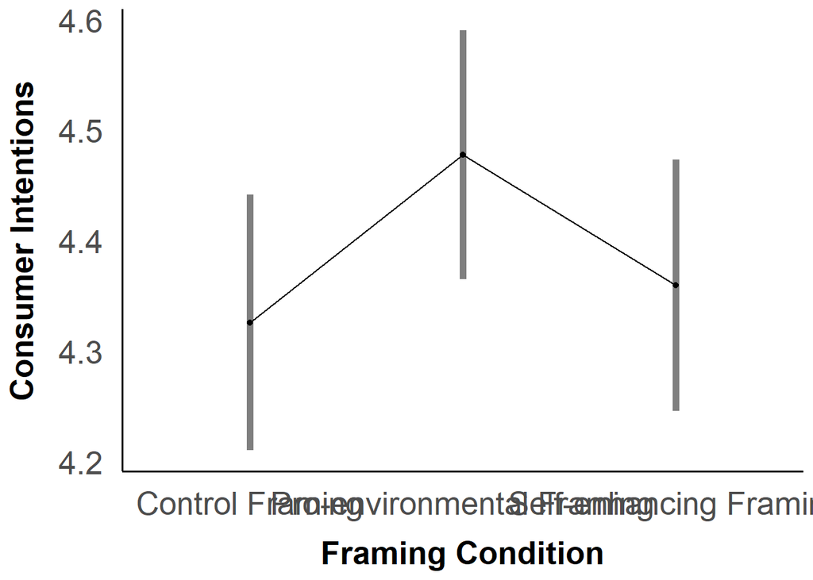

```r
# without data overlaid
emmip(mod_mice, ~ framing_condition, CIs = TRUE, CIarg = list(lwd = 2, alpha = 0.5), xlab = "Framing Condition", ylab = "Consumer Intentions") + scale_x_discrete(breaks=c("control_framing","pro_env_framing","self_enh_framing"),
        labels=c("Control Framing", "Pro-environmental Framing", "Self-enhancing Framing")) +theme_apa() + text_settings
```

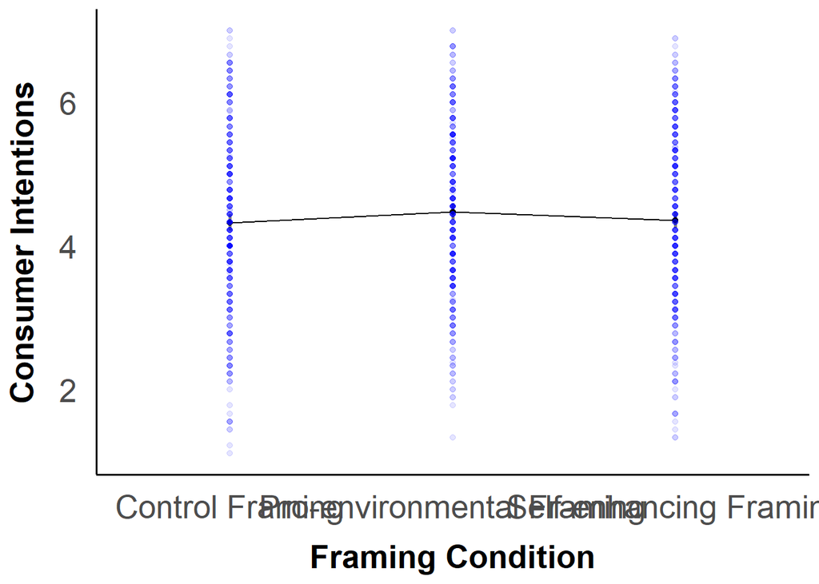

```r
# with data overlaid (scores averaged across imputations)
emmip(mod_mice, ~ framing_condition, CIs = TRUE, CIarg = list(lwd = 1, alpha = 0.5), xlab = "Framing Condition", ylab = "Consumer Intentions") + geom_point(data = average_df, aes(x = framing_condition, y = consumer_intentions), alpha = 0.1, color = "blue") + scale_x_discrete(breaks=c("control_framing","pro_env_framing","self_enh_framing"),
        labels=c("Control Framing", "Pro-environmental Framing", "Self-enhancing Framing")) + theme_apa() + text_settings
```

## Norm Condition

> > H2: Consumer intentions/behaviors will be lower in each norm condition compared to the control norm condition.

Comparing each level of norm condition

```r
norm_emmeans
```

```
##  norm_condition   emmean     SE   df lower.CL upper.CL
##  control_norm       4.43 0.0732 1038     4.29     4.58
##  descriptive_norm   4.40 0.0740 1038     4.26     4.55
##  convention_norm    4.50 0.0744 1038     4.36     4.65
##  social_norm        4.28 0.0751 1038     4.13     4.42
##  moral_norm         4.33 0.0763 1038     4.18     4.48
##
## Results are averaged over the levels of: framing_condition, Gender
## Confidence level used: 0.95
```

```r
# custom contrasts
Control_N_EMM <- c(1,0,0,0,0)
DN_EMM <- c(0,1,0,0,0)
Conv_EMM <- c(0,0,1,0,0)
SN_EMM <- c(0,0,0,1,0)
MN_EMM <- c(0,0,0,0,1)

norm_comparisons <- contrast(norm_emmeans,
                          method = list("Descriptive Norm - Control" = DN_EMM - Control_N_EMM,
                                        "Convention - Control" = Conv_EMM - Control_N_EMM,
                                        "Social Norm - Control" = SN_EMM - Control_N_EMM,
                                        "Moral Norm - Control" = MN_EMM - Control_N_EMM), adjust = "none")


norm_comparisons %>%
  knitr::kable(digits = c(NA,2,2,2,2,3))
```

| contrast | estimate | SE | df | t.ratio | p.value |
| --- | --- | --- | --- | --- | --- |
| Descriptive Norm - Control | -0.03 | 0.1 | 1038 | -0.29 | 0.774 |
| Convention - Control | 0.07 | 0.1 | 1038 | 0.68 | 0.499 |
| Social Norm - Control | -0.16 | 0.1 | 1038 | -1.50 | 0.134 |
| Moral Norm - Control | -0.10 | 0.1 | 1038 | -1.00 | 0.320 |

```r
# confidence intervals
norm_comparisons %>% confint() %>%
  knitr::kable(digits = 2)
```

| contrast | estimate | SE | df | lower.CL | upper.CL |
| --- | --- | --- | --- | --- | --- |
| Descriptive Norm - Control | -0.03 | 0.1 | 1038 | -0.23 | 0.17 |
| Convention - Control | 0.07 | 0.1 | 1038 | -0.13 | 0.27 |
| Social Norm - Control | -0.16 | 0.1 | 1038 | -0.36 | 0.05 |
| Moral Norm - Control | -0.10 | 0.1 | 1038 | -0.31 | 0.10 |

```r
# effect sizes
eff_size(norm_comparisons, sigma = sigma_pool, edf = df_resid_pool) %>% knitr::kable(digits = 2)
```

| contrast | effect.size | SE | df | lower.CL | upper.CL |
| --- | --- | --- | --- | --- | --- |
| (Descriptive Norm - Control) - (Convention - Control) | -0.09 | 0.1 | 1038 | -0.28 | 0.10 |
| (Descriptive Norm - Control) - (Social Norm - Control) | 0.12 | 0.1 | 1038 | -0.07 | 0.31 |
| (Descriptive Norm - Control) - (Moral Norm - Control) | 0.07 | 0.1 | 1038 | -0.12 | 0.26 |
| (Convention - Control) - (Social Norm - Control) | 0.21 | 0.1 | 1038 | 0.02 | 0.40 |
| (Convention - Control) - (Moral Norm - Control) | 0.16 | 0.1 | 1038 | -0.03 | 0.36 |
| (Social Norm - Control) - (Moral Norm - Control) | -0.05 | 0.1 | 1038 | -0.24 | 0.15 |

Exploratory multiple comparisons

```r
# All pairwise comparisons of framing conditions
norm_means2 <- emmeans(mod_mice, pairwise ~ norm_condition, adjust = "none")

norm_comparisons2 <- contrast(norm_means2)
norm_comparisons2 %>%
  knitr::kable(digits = c(NA,2,2,2,2,3))
```

| contrast | estimate | SE | df | t.ratio | p.value |
| --- | --- | --- | --- | --- | --- |
| control_norm effect | 0.04 | 0.07 | 1038 | 0.67 | 0.625 |
| descriptive_norm effect | 0.01 | 0.07 | 1038 | 0.22 | 0.827 |
| convention_norm effect | 0.11 | 0.07 | 1038 | 1.72 | 0.231 |
| social_norm effect | -0.11 | 0.07 | 1038 | -1.68 | 0.231 |
| moral_norm effect | -0.06 | 0.07 | 1038 | -0.90 | 0.616 |

```r
# confidence intervals
norm_comparisons2 %>% confint() %>%
  knitr::kable(digits = 2)
```

| contrast | estimate | SE | df | lower.CL | upper.CL |
| --- | --- | --- | --- | --- | --- |
| control_norm effect | 0.04 | 0.07 | 1038 | -0.12 | 0.21 |
| descriptive_norm effect | 0.01 | 0.07 | 1038 | -0.16 | 0.18 |
| convention_norm effect | 0.11 | 0.07 | 1038 | -0.06 | 0.29 |
| social_norm effect | -0.11 | 0.07 | 1038 | -0.28 | 0.06 |
| moral_norm effect | -0.06 | 0.07 | 1038 | -0.23 | 0.11 |

```r
# effect sizes
eff_size(norm_comparisons2, sigma = sigma_pool, edf = df_resid_pool) %>% knitr::kable(digits = 2)
```

| contrast | effect.size | SE | df | lower.CL | upper.CL |
| --- | --- | --- | --- | --- | --- |
| control_norm effect - descriptive_norm effect | 0.03 | 0.1 | 1038 | -0.16 | 0.22 |
| control_norm effect - convention_norm effect | -0.07 | 0.1 | 1038 | -0.26 | 0.12 |
| control_norm effect - social_norm effect | 0.15 | 0.1 | 1038 | -0.04 | 0.34 |
| control_norm effect - moral_norm effect | 0.10 | 0.1 | 1038 | -0.09 | 0.29 |
| descriptive_norm effect - convention_norm effect | -0.09 | 0.1 | 1038 | -0.29 | 0.10 |
| descriptive_norm effect - social_norm effect | 0.12 | 0.1 | 1038 | -0.07 | 0.31 |
| descriptive_norm effect - moral_norm effect | 0.07 | 0.1 | 1038 | -0.12 | 0.26 |
| convention_norm effect - social_norm effect | 0.21 | 0.1 | 1038 | 0.02 | 0.40 |
| convention_norm effect - moral_norm effect | 0.16 | 0.1 | 1038 | -0.03 | 0.36 |
| social_norm effect - moral_norm effect | -0.05 | 0.1 | 1038 | -0.24 | 0.15 |

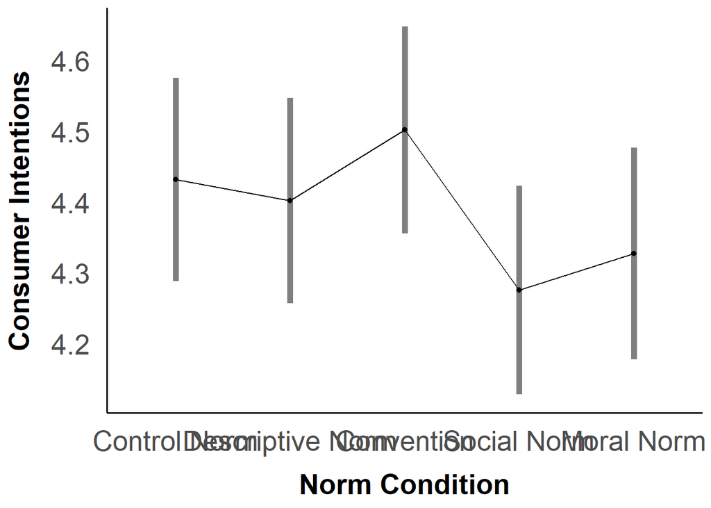

```r
# without data overlaid
emmip(mod_mice, ~ norm_condition, CIs = TRUE, CIarg = list(lwd = 2, alpha = 0.5), xlab = "Norm Condition", ylab = "Consumer Intentions") + scale_x_discrete(breaks=c("control_norm","descriptive_norm", "convention_norm", "social_norm", "moral_norm"),
        labels=c("Control Norm", "Descriptive Norm", "Convention", "Social Norm", "Moral Norm")) + theme_apa() + text_settings
```

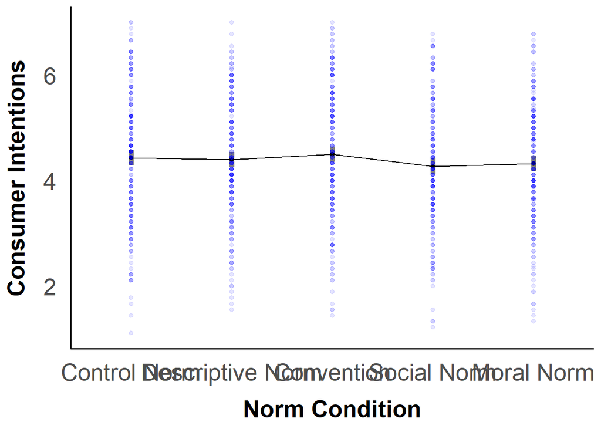

```r
# with data overlaid
emmip(mod_mice, ~ norm_condition, CIs = TRUE, xlab = "Norm Condition", ylab = "Consumer Intentions") + geom_point(data = average_df, aes(x = norm_condition, y = consumer_intentions), alpha = 0.1, color = "blue") + scale_x_discrete(breaks=c("control_norm","descriptive_norm", "convention_norm", "social_norm", "moral_norm"), labels=c("Control Norm", "Descriptive Norm", "Convention", "Social Norm", "Moral Norm")) + theme_apa() + text_settings
```

## Framing X Norm

> > H3: There will be a two-way interaction between framing & norm condition such that the effect of each norm will be stronger in the self-enhancing framing than in the pro-environmental or control framing conditions.

Comparing differences in cell means

```r
cell_emmeans
```

```
##  norm_condition   framing_condition emmean    SE   df lower.CL upper.CL
##  control_norm     control_framing     4.45 0.123 1038     4.21     4.69
##  descriptive_norm control_framing     4.29 0.133 1038     4.03     4.55
##  convention_norm  control_framing     4.50 0.137 1038     4.23     4.77
##  social_norm      control_framing     4.16 0.116 1038     3.93     4.39
##  moral_norm       control_framing     4.23 0.144 1038     3.95     4.51
##  control_norm     pro_env_framing     4.61 0.128 1038     4.36     4.86
##  descriptive_norm pro_env_framing     4.44 0.128 1038     4.19     4.69
##  convention_norm  pro_env_framing     4.54 0.119 1038     4.30     4.77
##  social_norm      pro_env_framing     4.42 0.134 1038     4.16     4.69
##  moral_norm       pro_env_framing     4.38 0.121 1038     4.14     4.61
##  control_norm     self_enh_framing    4.24 0.127 1038     3.99     4.48
##  descriptive_norm self_enh_framing    4.47 0.122 1038     4.24     4.71
##  convention_norm  self_enh_framing    4.47 0.130 1038     4.21     4.72
##  social_norm      self_enh_framing    4.24 0.137 1038     3.98     4.51
##  moral_norm       self_enh_framing    4.38 0.129 1038     4.12     4.63
##
## Results are averaged over the levels of: Gender
## Confidence level used: 0.95
```

```r
# custom contrasts
cf_cn_emm <- c(1,rep(0,14)) ## control framings
cf_dn_emm <- c(0,1,rep(0,13))
cf_conv_emm <- c(0,0,1,rep(0,12))
cf_sn_emm <- c(0,0,0,1,rep(0,11))
cf_mn_emm <- c(0,0,0,0,1,rep(0,10))

pf_cn_emm <- c(0,0,0,0,0,1,rep(0,9)) ## pro-environmental framings
pf_dn_emm <- c(0,0,0,0,0,0,1,rep(0,8))
pf_conv_emm <- c(rep(0,7),1,(rep(0,7)))
pf_sn_emm <- c(rep(0,8),1,(rep(0,6)))
pf_mn_emm <- c(rep(0,9),1,(rep(0,5)))

sf_cn_emm <- c(rep(0,10),1,(rep(0,4))) ## self-enhancing framings
sf_dn_emm <- c(rep(0,11),1,(rep(0,3)))
sf_conv_emm <- c(rep(0,12),1,(rep(0,2)))
sf_sn_emm <- c(rep(0,13),1,0)
sf_mn_emm <- c(rep(0,14),1)

FxN_comparisons <- contrast(cell_emmeans,
                          method = list("Control Frame + DN - Control Frame + Ctrl" = cf_dn_emm - cf_cn_emm,
                                        "Control Frame + Conv - Control Frame + Ctrl" = cf_conv_emm - cf_cn_emm,
                                        "Control Frame + SN - Control Frame + Ctrl" = cf_sn_emm - cf_cn_emm,
                                        "Control Frame + MN - Control Frame + Ctrl" = cf_mn_emm - cf_cn_emm,
                                        "PE Frame + DN - PE Frame + Ctrl" = pf_dn_emm - pf_cn_emm,
                                        "PE Frame + Conv - PE Frame + Ctrl" = pf_conv_emm - pf_cn_emm,
                                        "PE Frame + SN - PE Frame + Ctrl" = pf_sn_emm - pf_cn_emm,
                                        "PE Frame + MN - PE Frame + Ctrl" = pf_mn_emm - pf_cn_emm,
                                        "SE Frame + DN - SE Frame + Ctrl" = sf_dn_emm - sf_cn_emm,
                                        "SE Frame + Conv - SE Frame + Ctrl" = sf_conv_emm - sf_cn_emm,
                                        "SE Frame + SN - SE Frame + Ctrl" = sf_sn_emm - sf_cn_emm,
                                        "SE Frame + MN - SE Frame + Ctrl" = sf_mn_emm - sf_cn_emm), adjust = "none")

FxN_comparisons %>%
  knitr::kable(digits = c(NA,2,2,2,2,3))
```

| contrast | estimate | SE | df | t.ratio | p.value |
| --- | --- | --- | --- | --- | --- |
| Control Frame + DN - Control Frame + Ctrl | -0.16 | 0.18 | 1038 | -0.87 | 0.384 |
| Control Frame + Conv - Control Frame + Ctrl | 0.05 | 0.18 | 1038 | 0.27 | 0.783 |
| Control Frame + SN - Control Frame + Ctrl | -0.29 | 0.17 | 1038 | -1.71 | 0.088 |
| Control Frame + MN - Control Frame + Ctrl | -0.22 | 0.19 | 1038 | -1.16 | 0.246 |
| PE Frame + DN - PE Frame + Ctrl | -0.17 | 0.18 | 1038 | -0.94 | 0.349 |
| PE Frame + Conv - PE Frame + Ctrl | -0.07 | 0.17 | 1038 | -0.42 | 0.671 |
| PE Frame + SN - PE Frame + Ctrl | -0.19 | 0.19 | 1038 | -1.02 | 0.310 |
| PE Frame + MN - PE Frame + Ctrl | -0.23 | 0.18 | 1038 | -1.33 | 0.183 |
| SE Frame + DN - SE Frame + Ctrl | 0.24 | 0.18 | 1038 | 1.36 | 0.174 |
| SE Frame + Conv - SE Frame + Ctrl | 0.23 | 0.18 | 1038 | 1.29 | 0.198 |
| SE Frame + SN - SE Frame + Ctrl | 0.01 | 0.19 | 1038 | 0.05 | 0.962 |
| SE Frame + MN - SE Frame + Ctrl | 0.14 | 0.18 | 1038 | 0.78 | 0.435 |

```r
# confidence intervals
FxN_comparisons %>% confint() %>%
  knitr::kable(digits = 2)
```

| contrast | estimate | SE | df | lower.CL | upper.CL |
| --- | --- | --- | --- | --- | --- |
| Control Frame + DN - Control Frame + Ctrl | -0.16 | 0.18 | 1038 | -0.51 | 0.20 |
| Control Frame + Conv - Control Frame + Ctrl | 0.05 | 0.18 | 1038 | -0.31 | 0.41 |
| Control Frame + SN - Control Frame + Ctrl | -0.29 | 0.17 | 1038 | -0.62 | 0.04 |
| Control Frame + MN - Control Frame + Ctrl | -0.22 | 0.19 | 1038 | -0.59 | 0.15 |
| PE Frame + DN - PE Frame + Ctrl | -0.17 | 0.18 | 1038 | -0.52 | 0.19 |
| PE Frame + Conv - PE Frame + Ctrl | -0.07 | 0.17 | 1038 | -0.42 | 0.27 |
| PE Frame + SN - PE Frame + Ctrl | -0.19 | 0.19 | 1038 | -0.55 | 0.18 |
| PE Frame + MN - PE Frame + Ctrl | -0.23 | 0.18 | 1038 | -0.58 | 0.11 |
| SE Frame + DN - SE Frame + Ctrl | 0.24 | 0.18 | 1038 | -0.11 | 0.58 |
| SE Frame + Conv - SE Frame + Ctrl | 0.23 | 0.18 | 1038 | -0.12 | 0.59 |
| SE Frame + SN - SE Frame + Ctrl | 0.01 | 0.19 | 1038 | -0.36 | 0.38 |
| SE Frame + MN - SE Frame + Ctrl | 0.14 | 0.18 | 1038 | -0.21 | 0.49 |

Pairwise comparisons

```r
FxN_comparisons
```

```
##  contrast                                    estimate    SE   df t.ratio
##  Control Frame + DN - Control Frame + Ctrl   -0.15760 0.181 1038  -0.871
##  Control Frame + Conv - Control Frame + Ctrl  0.05069 0.184 1038   0.275
##  Control Frame + SN - Control Frame + Ctrl   -0.28940 0.169 1038  -1.708
##  Control Frame + MN - Control Frame + Ctrl   -0.21955 0.189 1038  -1.160
##  PE Frame + DN - PE Frame + Ctrl             -0.16950 0.181 1038  -0.936
##  PE Frame + Conv - PE Frame + Ctrl           -0.07396 0.174 1038  -0.425
##  PE Frame + SN - PE Frame + Ctrl             -0.18785 0.185 1038  -1.015
##  PE Frame + MN - PE Frame + Ctrl             -0.23430 0.176 1038  -1.332
##  SE Frame + DN - SE Frame + Ctrl              0.23825 0.175 1038   1.359
##  SE Frame + Conv - SE Frame + Ctrl            0.23377 0.181 1038   1.288
##  SE Frame + SN - SE Frame + Ctrl              0.00881 0.187 1038   0.047
##  SE Frame + MN - SE Frame + Ctrl              0.14069 0.180 1038   0.780
##  p.value
##   0.3842
##   0.7835
##   0.0880
##   0.2462
##   0.3494
##   0.6713
##   0.3103
##   0.1831
##   0.1743
##   0.1979
##   0.9624
##   0.4353
##
## Results are averaged over the levels of: Gender
```

```r
# custom contrasts
control_DN_vs_C <- c(1,rep(0,11))
control_Conv_vs_C <- c(0,1,rep(0,10))
control_SN_vs_C <- c(0,0,1,rep(0,9))
control_MN_vs_C <- c(0,0,0,1,rep(0,8))

p_DN_vs_C <- c(rep(0,4),1,rep(0,7))
p_Conv_vs_C <- c(rep(0,5),1,(rep(0,6)))
p_SN_vs_C <- c(rep(0,6),1,rep(0,5))
p_MN_vs_C <- c(rep(0,7),1,rep(0,4))

s_DN_vs_C <- c(rep(0,8),1,rep(0,3))
s_Conv_vs_C <- c(rep(0,9),1,rep(0,2))
s_SN_vs_C <- c(rep(0,10),1,0)
s_MN_vs_C <- c(rep(0,11),1)


FxN_pairwise <- contrast(FxN_comparisons, method = list("SE vs Control: DN - Control" = s_DN_vs_C - control_DN_vs_C,
                                                        "SE vs Control: Conv - Control" = s_Conv_vs_C - control_Conv_vs_C,
                                                        "SE vs Control: SN - Control" = s_SN_vs_C - control_SN_vs_C,
                                                        "SE vs Control: MN - Control" = s_MN_vs_C - control_MN_vs_C,
                                                        "SE vs PE: DN - Control" = s_DN_vs_C - p_DN_vs_C,
                                                        "SE vs PE: Conv - Control" = s_Conv_vs_C - p_Conv_vs_C,
                                                        "SE vs PE: SN - Control" = s_SN_vs_C - p_SN_vs_C,
                                                        "SE vs PE: MN - Control" = s_MN_vs_C - p_MN_vs_C,
                                                        "PE vs Control: DN - Control" = p_DN_vs_C - control_DN_vs_C,
                                                        "PE vs Control: Conv - Control" = p_Conv_vs_C - control_Conv_vs_C,
                                                        "PE vs Control: SN - Control" = p_SN_vs_C - control_SN_vs_C,
                                                        "PE vs Control: MN - Control" = p_MN_vs_C - control_MN_vs_C), adjust = "none")


FxN_pairwise %>% knitr::kable(digits = c(NA,2,2,2,2,3))
```

| contrast | estimate | SE | df | t.ratio | p.value |
| --- | --- | --- | --- | --- | --- |
| SE vs Control: DN - Control | 0.40 | 0.25 | 1038 | 1.57 | 0.117 |
| SE vs Control: Conv - Control | 0.18 | 0.26 | 1038 | 0.71 | 0.481 |
| SE vs Control: SN - Control | 0.30 | 0.25 | 1038 | 1.18 | 0.238 |
| SE vs Control: MN - Control | 0.36 | 0.26 | 1038 | 1.38 | 0.169 |
| SE vs PE: DN - Control | 0.41 | 0.25 | 1038 | 1.62 | 0.106 |
| SE vs PE: Conv - Control | 0.31 | 0.25 | 1038 | 1.22 | 0.221 |
| SE vs PE: SN - Control | 0.20 | 0.26 | 1038 | 0.75 | 0.455 |
| SE vs PE: MN - Control | 0.37 | 0.25 | 1038 | 1.49 | 0.137 |
| PE vs Control: DN - Control | -0.01 | 0.26 | 1038 | -0.05 | 0.963 |
| PE vs Control: Conv - Control | -0.12 | 0.25 | 1038 | -0.49 | 0.624 |
| PE vs Control: SN - Control | 0.10 | 0.25 | 1038 | 0.40 | 0.686 |
| PE vs Control: MN - Control | -0.01 | 0.26 | 1038 | -0.06 | 0.954 |

```r
# confidencce intervals
FxN_pairwise %>%
  confint() %>%
  knitr::kable(digits = 2)
```

| contrast | estimate | SE | df | lower.CL | upper.CL |
| --- | --- | --- | --- | --- | --- |
| SE vs Control: DN - Control | 0.40 | 0.25 | 1038 | -0.10 | 0.89 |
| SE vs Control: Conv - Control | 0.18 | 0.26 | 1038 | -0.33 | 0.69 |
| SE vs Control: SN - Control | 0.30 | 0.25 | 1038 | -0.20 | 0.79 |
| SE vs Control: MN - Control | 0.36 | 0.26 | 1038 | -0.15 | 0.87 |
| SE vs PE: DN - Control | 0.41 | 0.25 | 1038 | -0.09 | 0.90 |
| SE vs PE: Conv - Control | 0.31 | 0.25 | 1038 | -0.19 | 0.80 |
| SE vs PE: SN - Control | 0.20 | 0.26 | 1038 | -0.32 | 0.71 |
| SE vs PE: MN - Control | 0.37 | 0.25 | 1038 | -0.12 | 0.87 |
| PE vs Control: DN - Control | -0.01 | 0.26 | 1038 | -0.51 | 0.49 |
| PE vs Control: Conv - Control | -0.12 | 0.25 | 1038 | -0.62 | 0.37 |
| PE vs Control: SN - Control | 0.10 | 0.25 | 1038 | -0.39 | 0.59 |
| PE vs Control: MN - Control | -0.01 | 0.26 | 1038 | -0.52 | 0.49 |

```r
# effect sizes
eff_size(FxN_comparisons, method = list("SE vs Control: DN - Control" = s_DN_vs_C - control_DN_vs_C,
                                                        "SE vs Control: Conv - Control" = s_Conv_vs_C - control_Conv_vs_C,
                                                        "SE vs Control: SN - Control" = s_SN_vs_C - control_SN_vs_C,
                                                        "SE vs Control: MN - Control" = s_MN_vs_C - control_MN_vs_C,
                                                        "SE vs PE: DN - Control" = s_DN_vs_C - p_DN_vs_C,
                                                        "SE vs PE: Conv - Control" = s_Conv_vs_C - p_Conv_vs_C,
                                                        "SE vs PE: SN - Control" = s_SN_vs_C - p_SN_vs_C,
                                                        "SE vs PE: MN - Control" = s_MN_vs_C - p_MN_vs_C,
                                                        "PE vs Control: DN - Control" = p_DN_vs_C - control_DN_vs_C,
                                                        "PE vs Control: Conv - Control" = p_Conv_vs_C - control_Conv_vs_C,
                                                        "PE vs Control: SN - Control" = p_SN_vs_C - control_SN_vs_C,
                                                        "PE vs Control: MN - Control" = p_MN_vs_C - control_MN_vs_C), sigma = sigma_pool, edf = df_resid_pool) %>% knitr::kable(digits = 2)
```

| contrast | effect.size | SE | df | lower.CL | upper.CL |
| --- | --- | --- | --- | --- | --- |
| SE vs Control: DN - Control | 0.37 | 0.24 | 1038 | -0.09 | 0.83 |
| SE vs Control: Conv - Control | 0.17 | 0.24 | 1038 | -0.31 | 0.65 |
| SE vs Control: SN - Control | 0.28 | 0.24 | 1038 | -0.18 | 0.74 |
| SE vs Control: MN - Control | 0.34 | 0.24 | 1038 | -0.14 | 0.82 |
| SE vs PE: DN - Control | 0.38 | 0.24 | 1038 | -0.08 | 0.84 |
| SE vs PE: Conv - Control | 0.29 | 0.24 | 1038 | -0.17 | 0.75 |
| SE vs PE: SN - Control | 0.18 | 0.25 | 1038 | -0.30 | 0.67 |
| SE vs PE: MN - Control | 0.35 | 0.24 | 1038 | -0.11 | 0.81 |
| PE vs Control: DN - Control | -0.01 | 0.24 | 1038 | -0.48 | 0.46 |
| PE vs Control: Conv - Control | -0.12 | 0.24 | 1038 | -0.58 | 0.35 |
| PE vs Control: SN - Control | 0.10 | 0.24 | 1038 | -0.37 | 0.56 |
| PE vs Control: MN - Control | -0.01 | 0.24 | 1038 | -0.49 | 0.46 |

Exploratory multiple comparisons

```r
# All pairwise comparisons of norm conditions across framing conditions
norm_means2 <- emmeans(mod_mice, pairwise ~ norm_condition | framing_condition, adjust = "none")

norm_means2$emmeans %>% knitr::kable(digits = 2)
```

| norm_condition | framing_condition | emmean | SE | df | lower.CL | upper.CL |
| --- | --- | --- | --- | --- | --- | --- |
| control_norm | control_framing | 4.45 | 0.12 | 1038 | 4.21 | 4.69 |
| descriptive_norm | control_framing | 4.29 | 0.13 | 1038 | 4.03 | 4.55 |
| convention_norm | control_framing | 4.50 | 0.14 | 1038 | 4.23 | 4.77 |
| social_norm | control_framing | 4.16 | 0.12 | 1038 | 3.93 | 4.39 |
| moral_norm | control_framing | 4.23 | 0.14 | 1038 | 3.95 | 4.51 |
| control_norm | pro_env_framing | 4.61 | 0.13 | 1038 | 4.36 | 4.86 |
| descriptive_norm | pro_env_framing | 4.44 | 0.13 | 1038 | 4.19 | 4.69 |
| convention_norm | pro_env_framing | 4.54 | 0.12 | 1038 | 4.30 | 4.77 |
| social_norm | pro_env_framing | 4.42 | 0.13 | 1038 | 4.16 | 4.69 |
| moral_norm | pro_env_framing | 4.38 | 0.12 | 1038 | 4.14 | 4.61 |
| control_norm | self_enh_framing | 4.24 | 0.13 | 1038 | 3.99 | 4.48 |
| descriptive_norm | self_enh_framing | 4.47 | 0.12 | 1038 | 4.24 | 4.71 |
| convention_norm | self_enh_framing | 4.47 | 0.13 | 1038 | 4.21 | 4.72 |
| social_norm | self_enh_framing | 4.24 | 0.14 | 1038 | 3.98 | 4.51 |
| moral_norm | self_enh_framing | 4.38 | 0.13 | 1038 | 4.12 | 4.63 |

```r
norm_comparisons2 <- norm_means2$contrasts
norm_comparisons2 %>%
  knitr::kable(digits = c(NA,NA,2,2,2,2,3))
```

| contrast | framing_condition | estimate | SE | df | t.ratio | p.value |
| --- | --- | --- | --- | --- | --- | --- |
| control_norm - descriptive_norm | control_framing | 0.16 | 0.18 | 1038 | 0.87 | 0.384 |
| control_norm - convention_norm | control_framing | -0.05 | 0.18 | 1038 | -0.27 | 0.783 |
| control_norm - social_norm | control_framing | 0.29 | 0.17 | 1038 | 1.71 | 0.088 |
| control_norm - moral_norm | control_framing | 0.22 | 0.19 | 1038 | 1.16 | 0.246 |
| descriptive_norm - convention_norm | control_framing | -0.21 | 0.19 | 1038 | -1.09 | 0.275 |
| descriptive_norm - social_norm | control_framing | 0.13 | 0.18 | 1038 | 0.75 | 0.455 |
| descriptive_norm - moral_norm | control_framing | 0.06 | 0.20 | 1038 | 0.32 | 0.751 |
| convention_norm - social_norm | control_framing | 0.34 | 0.18 | 1038 | 1.89 | 0.059 |
| convention_norm - moral_norm | control_framing | 0.27 | 0.20 | 1038 | 1.36 | 0.173 |
| social_norm - moral_norm | control_framing | -0.07 | 0.18 | 1038 | -0.38 | 0.705 |
| control_norm - descriptive_norm | pro_env_framing | 0.17 | 0.18 | 1038 | 0.94 | 0.349 |
| control_norm - convention_norm | pro_env_framing | 0.07 | 0.17 | 1038 | 0.42 | 0.671 |
| control_norm - social_norm | pro_env_framing | 0.19 | 0.19 | 1038 | 1.02 | 0.310 |
| control_norm - moral_norm | pro_env_framing | 0.23 | 0.18 | 1038 | 1.33 | 0.183 |
| descriptive_norm - convention_norm | pro_env_framing | -0.10 | 0.17 | 1038 | -0.55 | 0.583 |
| descriptive_norm - social_norm | pro_env_framing | 0.02 | 0.18 | 1038 | 0.10 | 0.921 |
| descriptive_norm - moral_norm | pro_env_framing | 0.06 | 0.18 | 1038 | 0.37 | 0.713 |
| convention_norm - social_norm | pro_env_framing | 0.11 | 0.18 | 1038 | 0.64 | 0.522 |
| convention_norm - moral_norm | pro_env_framing | 0.16 | 0.17 | 1038 | 0.95 | 0.341 |
| social_norm - moral_norm | pro_env_framing | 0.05 | 0.18 | 1038 | 0.26 | 0.796 |
| control_norm - descriptive_norm | self_enh_framing | -0.24 | 0.18 | 1038 | -1.36 | 0.174 |
| control_norm - convention_norm | self_enh_framing | -0.23 | 0.18 | 1038 | -1.29 | 0.198 |
| control_norm - social_norm | self_enh_framing | -0.01 | 0.19 | 1038 | -0.05 | 0.962 |
| control_norm - moral_norm | self_enh_framing | -0.14 | 0.18 | 1038 | -0.78 | 0.435 |
| descriptive_norm - convention_norm | self_enh_framing | 0.00 | 0.18 | 1038 | 0.03 | 0.980 |
| descriptive_norm - social_norm | self_enh_framing | 0.23 | 0.18 | 1038 | 1.25 | 0.210 |
| descriptive_norm - moral_norm | self_enh_framing | 0.10 | 0.18 | 1038 | 0.55 | 0.581 |
| convention_norm - social_norm | self_enh_framing | 0.22 | 0.19 | 1038 | 1.20 | 0.232 |
| convention_norm - moral_norm | self_enh_framing | 0.09 | 0.18 | 1038 | 0.51 | 0.613 |
| social_norm - moral_norm | self_enh_framing | -0.13 | 0.19 | 1038 | -0.70 | 0.482 |

```r
# confidence intervals
norm_comparisons2 %>% confint() %>%
  knitr::kable(digits = 2)
```

| contrast | framing_condition | estimate | SE | df | lower.CL | upper.CL |
| --- | --- | --- | --- | --- | --- | --- |
| control_norm - descriptive_norm | control_framing | 0.16 | 0.18 | 1038 | -0.20 | 0.51 |
| control_norm - convention_norm | control_framing | -0.05 | 0.18 | 1038 | -0.41 | 0.31 |
| control_norm - social_norm | control_framing | 0.29 | 0.17 | 1038 | -0.04 | 0.62 |
| control_norm - moral_norm | control_framing | 0.22 | 0.19 | 1038 | -0.15 | 0.59 |
| descriptive_norm - convention_norm | control_framing | -0.21 | 0.19 | 1038 | -0.58 | 0.17 |
| descriptive_norm - social_norm | control_framing | 0.13 | 0.18 | 1038 | -0.21 | 0.48 |
| descriptive_norm - moral_norm | control_framing | 0.06 | 0.20 | 1038 | -0.32 | 0.45 |
| convention_norm - social_norm | control_framing | 0.34 | 0.18 | 1038 | -0.01 | 0.69 |
| convention_norm - moral_norm | control_framing | 0.27 | 0.20 | 1038 | -0.12 | 0.66 |
| social_norm - moral_norm | control_framing | -0.07 | 0.18 | 1038 | -0.43 | 0.29 |
| control_norm - descriptive_norm | pro_env_framing | 0.17 | 0.18 | 1038 | -0.19 | 0.52 |
| control_norm - convention_norm | pro_env_framing | 0.07 | 0.17 | 1038 | -0.27 | 0.42 |
| control_norm - social_norm | pro_env_framing | 0.19 | 0.19 | 1038 | -0.18 | 0.55 |
| control_norm - moral_norm | pro_env_framing | 0.23 | 0.18 | 1038 | -0.11 | 0.58 |
| descriptive_norm - convention_norm | pro_env_framing | -0.10 | 0.17 | 1038 | -0.44 | 0.25 |
| descriptive_norm - social_norm | pro_env_framing | 0.02 | 0.18 | 1038 | -0.34 | 0.38 |
| descriptive_norm - moral_norm | pro_env_framing | 0.06 | 0.18 | 1038 | -0.28 | 0.41 |
| convention_norm - social_norm | pro_env_framing | 0.11 | 0.18 | 1038 | -0.24 | 0.46 |
| convention_norm - moral_norm | pro_env_framing | 0.16 | 0.17 | 1038 | -0.17 | 0.49 |
| social_norm - moral_norm | pro_env_framing | 0.05 | 0.18 | 1038 | -0.31 | 0.40 |
| control_norm - descriptive_norm | self_enh_framing | -0.24 | 0.18 | 1038 | -0.58 | 0.11 |
| control_norm - convention_norm | self_enh_framing | -0.23 | 0.18 | 1038 | -0.59 | 0.12 |
| control_norm - social_norm | self_enh_framing | -0.01 | 0.19 | 1038 | -0.38 | 0.36 |
| control_norm - moral_norm | self_enh_framing | -0.14 | 0.18 | 1038 | -0.49 | 0.21 |
| descriptive_norm - convention_norm | self_enh_framing | 0.00 | 0.18 | 1038 | -0.34 | 0.35 |
| descriptive_norm - social_norm | self_enh_framing | 0.23 | 0.18 | 1038 | -0.13 | 0.59 |
| descriptive_norm - moral_norm | self_enh_framing | 0.10 | 0.18 | 1038 | -0.25 | 0.44 |
| convention_norm - social_norm | self_enh_framing | 0.22 | 0.19 | 1038 | -0.14 | 0.59 |
| convention_norm - moral_norm | self_enh_framing | 0.09 | 0.18 | 1038 | -0.27 | 0.45 |
| social_norm - moral_norm | self_enh_framing | -0.13 | 0.19 | 1038 | -0.50 | 0.24 |

```r
# effect sizes
eff_size(norm_comparisons2, sigma = sigma_pool, edf = df_resid_pool) %>% knitr::kable(digits = 2)
```

| contrast | framing_condition | effect.size | SE | df | lower.CL | upper.CL |
| --- | --- | --- | --- | --- | --- | --- |
| (control_norm - descriptive_norm) - (control_norm - convention_norm) | control_framing | 0.19 | 0.18 | 1038 | -0.16 | 0.55 |
| (control_norm - descriptive_norm) - (control_norm - social_norm) | control_framing | -0.12 | 0.17 | 1038 | -0.45 | 0.20 |
| (control_norm - descriptive_norm) - (control_norm - moral_norm) | control_framing | -0.06 | 0.18 | 1038 | -0.42 | 0.30 |
| (control_norm - descriptive_norm) - (descriptive_norm - convention_norm) | control_framing | 0.34 | 0.30 | 1038 | -0.25 | 0.94 |
| (control_norm - descriptive_norm) - (descriptive_norm - social_norm) | control_framing | 0.02 | 0.29 | 1038 | -0.55 | 0.60 |
| (control_norm - descriptive_norm) - (descriptive_norm - moral_norm) | control_framing | 0.09 | 0.30 | 1038 | -0.51 | 0.69 |
| (control_norm - descriptive_norm) - (convention_norm - social_norm) | control_framing | -0.17 | 0.24 | 1038 | -0.64 | 0.30 |
| (control_norm - descriptive_norm) - (convention_norm - moral_norm) | control_framing | -0.11 | 0.25 | 1038 | -0.60 | 0.39 |
| (control_norm - descriptive_norm) - (social_norm - moral_norm) | control_framing | 0.21 | 0.24 | 1038 | -0.26 | 0.69 |
| (control_norm - convention_norm) - (control_norm - social_norm) | control_framing | -0.32 | 0.17 | 1038 | -0.65 | 0.01 |
| (control_norm - convention_norm) - (control_norm - moral_norm) | control_framing | -0.25 | 0.19 | 1038 | -0.62 | 0.11 |
| (control_norm - convention_norm) - (descriptive_norm - convention_norm) | control_framing | 0.15 | 0.17 | 1038 | -0.19 | 0.48 |
| (control_norm - convention_norm) - (descriptive_norm - social_norm) | control_framing | -0.17 | 0.24 | 1038 | -0.64 | 0.30 |
| (control_norm - convention_norm) - (descriptive_norm - moral_norm) | control_framing | -0.11 | 0.25 | 1038 | -0.60 | 0.39 |
| (control_norm - convention_norm) - (convention_norm - social_norm) | control_framing | -0.37 | 0.30 | 1038 | -0.96 | 0.23 |
| (control_norm - convention_norm) - (convention_norm - moral_norm) | control_framing | -0.30 | 0.31 | 1038 | -0.91 | 0.31 |
| (control_norm - convention_norm) - (social_norm - moral_norm) | control_framing | 0.02 | 0.24 | 1038 | -0.46 | 0.50 |
| (control_norm - social_norm) - (control_norm - moral_norm) | control_framing | 0.07 | 0.17 | 1038 | -0.27 | 0.40 |
| (control_norm - social_norm) - (descriptive_norm - convention_norm) | control_framing | 0.47 | 0.24 | 1038 | 0.00 | 0.93 |
| (control_norm - social_norm) - (descriptive_norm - social_norm) | control_framing | 0.15 | 0.17 | 1038 | -0.19 | 0.48 |
| (control_norm - social_norm) - (descriptive_norm - moral_norm) | control_framing | 0.21 | 0.24 | 1038 | -0.26 | 0.69 |
| (control_norm - social_norm) - (convention_norm - social_norm) | control_framing | -0.05 | 0.17 | 1038 | -0.39 | 0.29 |
| (control_norm - social_norm) - (convention_norm - moral_norm) | control_framing | 0.02 | 0.24 | 1038 | -0.46 | 0.50 |
| (control_norm - social_norm) - (social_norm - moral_norm) | control_framing | 0.34 | 0.28 | 1038 | -0.21 | 0.89 |
| (control_norm - moral_norm) - (descriptive_norm - convention_norm) | control_framing | 0.40 | 0.25 | 1038 | -0.09 | 0.89 |
| (control_norm - moral_norm) - (descriptive_norm - social_norm) | control_framing | 0.08 | 0.24 | 1038 | -0.39 | 0.56 |
| (control_norm - moral_norm) - (descriptive_norm - moral_norm) | control_framing | 0.15 | 0.17 | 1038 | -0.19 | 0.48 |
| (control_norm - moral_norm) - (convention_norm - social_norm) | control_framing | -0.11 | 0.24 | 1038 | -0.59 | 0.37 |
| (control_norm - moral_norm) - (convention_norm - moral_norm) | control_framing | -0.05 | 0.17 | 1038 | -0.39 | 0.29 |
| (control_norm - moral_norm) - (social_norm - moral_norm) | control_framing | 0.27 | 0.16 | 1038 | -0.04 | 0.58 |

[output cut: 105 more lines]

Pairwise comparisons

```r
norm2_pairwise <- contrast(norm_comparisons2, "pairwise")

norm2_pairwise %>% knitr::kable(digits = c(NA,NA,2,2,2,2,3))
```

| contrast | framing_condition | estimate | SE | df | t.ratio | p.value |
| --- | --- | --- | --- | --- | --- | --- |
| (control_norm - descriptive_norm) - (control_norm - convention_norm) | control_framing | 0.21 | 0.19 | 1038 | 1.09 | 0.985 |
| (control_norm - descriptive_norm) - (control_norm - social_norm) | control_framing | -0.13 | 0.18 | 1038 | -0.75 | 0.999 |
| (control_norm - descriptive_norm) - (control_norm - moral_norm) | control_framing | -0.06 | 0.20 | 1038 | -0.32 | 1.000 |
| (control_norm - descriptive_norm) - (descriptive_norm - convention_norm) | control_framing | 0.37 | 0.32 | 1038 | 1.13 | 0.981 |
| (control_norm - descriptive_norm) - (descriptive_norm - social_norm) | control_framing | 0.03 | 0.31 | 1038 | 0.08 | 1.000 |
| (control_norm - descriptive_norm) - (descriptive_norm - moral_norm) | control_framing | 0.10 | 0.33 | 1038 | 0.29 | 1.000 |
| (control_norm - descriptive_norm) - (convention_norm - social_norm) | control_framing | -0.18 | 0.26 | 1038 | -0.72 | 0.999 |
| (control_norm - descriptive_norm) - (convention_norm - moral_norm) | control_framing | -0.11 | 0.27 | 1038 | -0.42 | 1.000 |
| (control_norm - descriptive_norm) - (social_norm - moral_norm) | control_framing | 0.23 | 0.26 | 1038 | 0.88 | 0.997 |
| (control_norm - convention_norm) - (control_norm - social_norm) | control_framing | -0.34 | 0.18 | 1038 | -1.89 | 0.675 |
| (control_norm - convention_norm) - (control_norm - moral_norm) | control_framing | -0.27 | 0.20 | 1038 | -1.36 | 0.938 |
| (control_norm - convention_norm) - (descriptive_norm - convention_norm) | control_framing | 0.16 | 0.18 | 1038 | 0.87 | 0.997 |
| (control_norm - convention_norm) - (descriptive_norm - social_norm) | control_framing | -0.18 | 0.26 | 1038 | -0.72 | 0.999 |
| (control_norm - convention_norm) - (descriptive_norm - moral_norm) | control_framing | -0.11 | 0.27 | 1038 | -0.42 | 1.000 |
| (control_norm - convention_norm) - (convention_norm - social_norm) | control_framing | -0.39 | 0.32 | 1038 | -1.21 | 0.970 |
| (control_norm - convention_norm) - (convention_norm - moral_norm) | control_framing | -0.32 | 0.33 | 1038 | -0.96 | 0.994 |
| (control_norm - convention_norm) - (social_norm - moral_norm) | control_framing | 0.02 | 0.26 | 1038 | 0.07 | 1.000 |
| (control_norm - social_norm) - (control_norm - moral_norm) | control_framing | 0.07 | 0.18 | 1038 | 0.38 | 1.000 |
| (control_norm - social_norm) - (descriptive_norm - convention_norm) | control_framing | 0.50 | 0.25 | 1038 | 1.95 | 0.633 |
| (control_norm - social_norm) - (descriptive_norm - social_norm) | control_framing | 0.16 | 0.18 | 1038 | 0.87 | 0.997 |
| (control_norm - social_norm) - (descriptive_norm - moral_norm) | control_framing | 0.23 | 0.26 | 1038 | 0.88 | 0.997 |
| (control_norm - social_norm) - (convention_norm - social_norm) | control_framing | -0.05 | 0.18 | 1038 | -0.27 | 1.000 |
| (control_norm - social_norm) - (convention_norm - moral_norm) | control_framing | 0.02 | 0.26 | 1038 | 0.07 | 1.000 |
| (control_norm - social_norm) - (social_norm - moral_norm) | control_framing | 0.36 | 0.30 | 1038 | 1.20 | 0.972 |
| (control_norm - moral_norm) - (descriptive_norm - convention_norm) | control_framing | 0.43 | 0.27 | 1038 | 1.59 | 0.851 |
| (control_norm - moral_norm) - (descriptive_norm - social_norm) | control_framing | 0.09 | 0.26 | 1038 | 0.34 | 1.000 |
| (control_norm - moral_norm) - (descriptive_norm - moral_norm) | control_framing | 0.16 | 0.18 | 1038 | 0.87 | 0.997 |
| (control_norm - moral_norm) - (convention_norm - social_norm) | control_framing | -0.12 | 0.26 | 1038 | -0.46 | 1.000 |
| (control_norm - moral_norm) - (convention_norm - moral_norm) | control_framing | -0.05 | 0.18 | 1038 | -0.27 | 1.000 |
| (control_norm - moral_norm) - (social_norm - moral_norm) | control_framing | 0.29 | 0.17 | 1038 | 1.71 | 0.791 |

[output cut: 105 more lines]

```r
# effect sizes
eff_size(norm2_pairwise, sigma = sigma_pool, edf = df_resid_pool) %>% knitr::kable(digits = 2)
```

| contrast | framing_condition | effect.size | SE | df | lower.CL | upper.CL |
| --- | --- | --- | --- | --- | --- | --- |
| ((control_norm - descriptive_norm) - (control_norm - convention_norm)) - ((control_norm - descriptive_norm) - (control_norm - social_norm)) | control_framing | 0.32 | 0.17 | 1038 | -0.01 | 0.65 |
| ((control_norm - descriptive_norm) - (control_norm - convention_norm)) - ((control_norm - descriptive_norm) - (control_norm - moral_norm)) | control_framing | 0.25 | 0.19 | 1038 | -0.11 | 0.62 |
| ((control_norm - descriptive_norm) - (control_norm - convention_norm)) - ((control_norm - descriptive_norm) - (descriptive_norm - convention_norm)) | control_framing | -0.15 | 0.17 | 1038 | -0.48 | 0.19 |
| ((control_norm - descriptive_norm) - (control_norm - convention_norm)) - ((control_norm - descriptive_norm) - (descriptive_norm - social_norm)) | control_framing | 0.17 | 0.24 | 1038 | -0.30 | 0.64 |
| ((control_norm - descriptive_norm) - (control_norm - convention_norm)) - ((control_norm - descriptive_norm) - (descriptive_norm - moral_norm)) | control_framing | 0.11 | 0.25 | 1038 | -0.39 | 0.60 |
| ((control_norm - descriptive_norm) - (control_norm - convention_norm)) - ((control_norm - descriptive_norm) - (convention_norm - social_norm)) | control_framing | 0.37 | 0.30 | 1038 | -0.23 | 0.96 |
| ((control_norm - descriptive_norm) - (control_norm - convention_norm)) - ((control_norm - descriptive_norm) - (convention_norm - moral_norm)) | control_framing | 0.30 | 0.31 | 1038 | -0.31 | 0.91 |
| ((control_norm - descriptive_norm) - (control_norm - convention_norm)) - ((control_norm - descriptive_norm) - (social_norm - moral_norm)) | control_framing | -0.02 | 0.24 | 1038 | -0.50 | 0.46 |
| ((control_norm - descriptive_norm) - (control_norm - convention_norm)) - ((control_norm - convention_norm) - (control_norm - social_norm)) | control_framing | 0.51 | 0.31 | 1038 | -0.09 | 1.11 |
| ((control_norm - descriptive_norm) - (control_norm - convention_norm)) - ((control_norm - convention_norm) - (control_norm - moral_norm)) | control_framing | 0.45 | 0.31 | 1038 | -0.17 | 1.07 |
| ((control_norm - descriptive_norm) - (control_norm - convention_norm)) - ((control_norm - convention_norm) - (descriptive_norm - convention_norm)) | control_framing | 0.05 | 0.17 | 1038 | -0.29 | 0.39 |
| ((control_norm - descriptive_norm) - (control_norm - convention_norm)) - ((control_norm - convention_norm) - (descriptive_norm - social_norm)) | control_framing | 0.37 | 0.30 | 1038 | -0.23 | 0.96 |
| ((control_norm - descriptive_norm) - (control_norm - convention_norm)) - ((control_norm - convention_norm) - (descriptive_norm - moral_norm)) | control_framing | 0.30 | 0.31 | 1038 | -0.31 | 0.91 |
| ((control_norm - descriptive_norm) - (control_norm - convention_norm)) - ((control_norm - convention_norm) - (convention_norm - social_norm)) | control_framing | 0.56 | 0.43 | 1038 | -0.29 | 1.41 |
| ((control_norm - descriptive_norm) - (control_norm - convention_norm)) - ((control_norm - convention_norm) - (convention_norm - moral_norm)) | control_framing | 0.50 | 0.44 | 1038 | -0.37 | 1.36 |
| ((control_norm - descriptive_norm) - (control_norm - convention_norm)) - ((control_norm - convention_norm) - (social_norm - moral_norm)) | control_framing | 0.18 | 0.35 | 1038 | -0.51 | 0.87 |
| ((control_norm - descriptive_norm) - (control_norm - convention_norm)) - ((control_norm - social_norm) - (control_norm - moral_norm)) | control_framing | 0.13 | 0.25 | 1038 | -0.36 | 0.62 |
| ((control_norm - descriptive_norm) - (control_norm - convention_norm)) - ((control_norm - social_norm) - (descriptive_norm - convention_norm)) | control_framing | -0.27 | 0.16 | 1038 | -0.58 | 0.04 |
| ((control_norm - descriptive_norm) - (control_norm - convention_norm)) - ((control_norm - social_norm) - (descriptive_norm - social_norm)) | control_framing | 0.05 | 0.17 | 1038 | -0.29 | 0.39 |
| ((control_norm - descriptive_norm) - (control_norm - convention_norm)) - ((control_norm - social_norm) - (descriptive_norm - moral_norm)) | control_framing | -0.02 | 0.24 | 1038 | -0.50 | 0.46 |
| ((control_norm - descriptive_norm) - (control_norm - convention_norm)) - ((control_norm - social_norm) - (convention_norm - social_norm)) | control_framing | 0.24 | 0.31 | 1038 | -0.36 | 0.85 |
| ((control_norm - descriptive_norm) - (control_norm - convention_norm)) - ((control_norm - social_norm) - (convention_norm - moral_norm)) | control_framing | 0.18 | 0.35 | 1038 | -0.51 | 0.87 |
| ((control_norm - descriptive_norm) - (control_norm - convention_norm)) - ((control_norm - social_norm) - (social_norm - moral_norm)) | control_framing | -0.14 | 0.33 | 1038 | -0.79 | 0.51 |
| ((control_norm - descriptive_norm) - (control_norm - convention_norm)) - ((control_norm - moral_norm) - (descriptive_norm - convention_norm)) | control_framing | -0.21 | 0.18 | 1038 | -0.55 | 0.14 |
| ((control_norm - descriptive_norm) - (control_norm - convention_norm)) - ((control_norm - moral_norm) - (descriptive_norm - social_norm)) | control_framing | 0.11 | 0.24 | 1038 | -0.37 | 0.59 |
| ((control_norm - descriptive_norm) - (control_norm - convention_norm)) - ((control_norm - moral_norm) - (descriptive_norm - moral_norm)) | control_framing | 0.05 | 0.17 | 1038 | -0.29 | 0.39 |
| ((control_norm - descriptive_norm) - (control_norm - convention_norm)) - ((control_norm - moral_norm) - (convention_norm - social_norm)) | control_framing | 0.31 | 0.35 | 1038 | -0.38 | 1.00 |
| ((control_norm - descriptive_norm) - (control_norm - convention_norm)) - ((control_norm - moral_norm) - (convention_norm - moral_norm)) | control_framing | 0.24 | 0.31 | 1038 | -0.36 | 0.85 |
| ((control_norm - descriptive_norm) - (control_norm - convention_norm)) - ((control_norm - moral_norm) - (social_norm - moral_norm)) | control_framing | -0.08 | 0.24 | 1038 | -0.54 | 0.39 |
| ((control_norm - descriptive_norm) - (control_norm - convention_norm)) - ((descriptive_norm - convention_norm) - (descriptive_norm - social_norm)) | control_framing | 0.51 | 0.31 | 1038 | -0.09 | 1.11 |

[output cut: 2940 more lines]

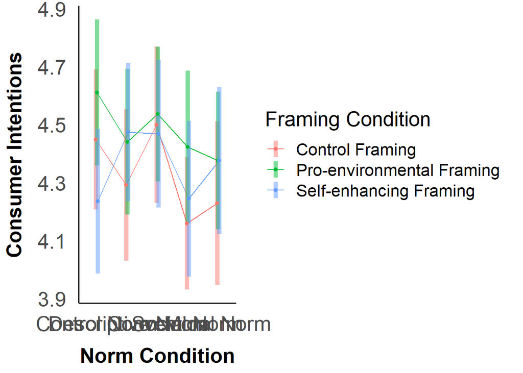

```r
# without data overlaid
emmip(mod_mice, framing_condition ~ norm_condition, CIs = TRUE, CIarg = list(lwd = 2, alpha = 0.5), xlab = "Norm Condition", ylab = "Consumer Intentions") + scale_x_discrete(breaks=c("control_norm","descriptive_norm", "convention_norm", "social_norm", "moral_norm"),
        labels=c("Control Norm", "Descriptive Norm", "Convention", "Social Norm", "Moral Norm")) + scale_colour_discrete(name = "Framing Condition", breaks=c("control_framing","pro_env_framing","self_enh_framing"), labels=c("Control Framing", "Pro-environmental Framing", "Self-enhancing Framing")) + theme_apa() + text_settings
```

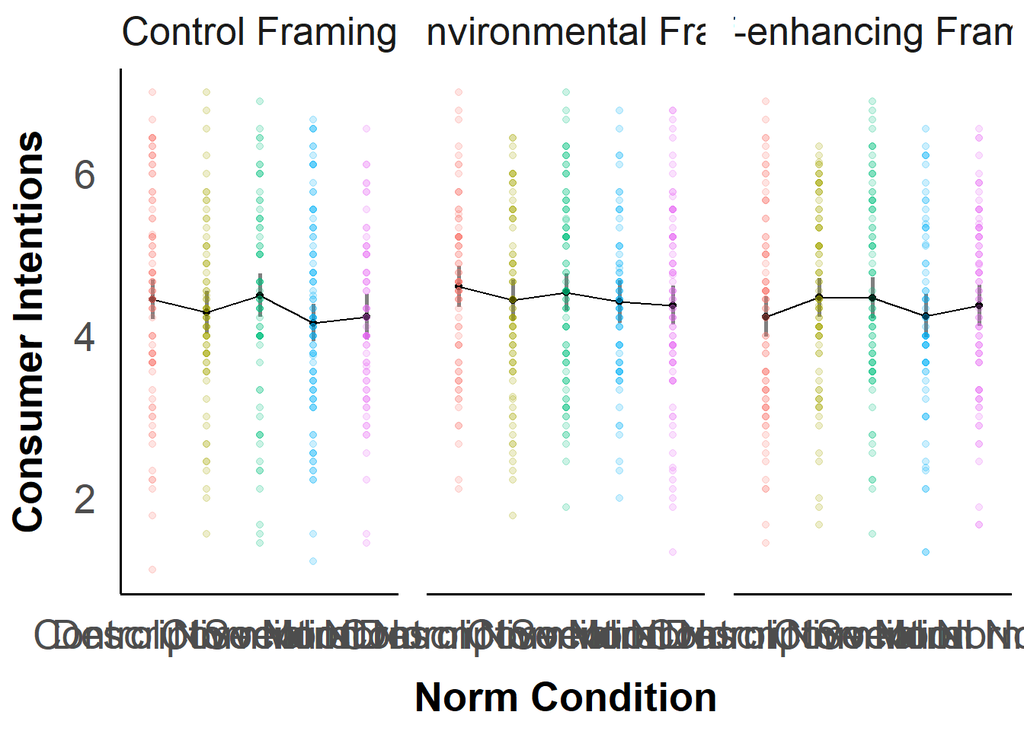

```r
# with data overlaid
emmip(mod_mice, ~ norm_condition | framing_condition, CIs = TRUE, CIarg = list(lwd = 1, alpha = 0.5), xlab = "Norm Condition", ylab = "Consumer Intentions") + geom_point(data = average_df, aes(x = norm_condition, y = consumer_intentions, color = norm_condition), alpha = 0.2, show.legend = FALSE) + scale_x_discrete(breaks=c("control_norm","descriptive_norm", "convention_norm", "social_norm", "moral_norm"),
        labels=c("Control Norm", "Descriptive Norm", "Convention", "Social Norm", "Moral Norm")) + facet_wrap(~framing_condition, labeller = labeller(framing_condition = frame_labs)) + theme_apa() + text_settings
```

## All control/framing conditions compared to control/control condition

> > Exploratory RQ2: Which combination of framing and norm condition produced the strongest reductions in consumer intentions compared to the control condition?

```r
cell_emmeans
```

```
##  norm_condition   framing_condition emmean    SE   df lower.CL upper.CL
##  control_norm     control_framing     4.45 0.123 1038     4.21     4.69
##  descriptive_norm control_framing     4.29 0.133 1038     4.03     4.55
##  convention_norm  control_framing     4.50 0.137 1038     4.23     4.77
##  social_norm      control_framing     4.16 0.116 1038     3.93     4.39
##  moral_norm       control_framing     4.23 0.144 1038     3.95     4.51
##  control_norm     pro_env_framing     4.61 0.128 1038     4.36     4.86
##  descriptive_norm pro_env_framing     4.44 0.128 1038     4.19     4.69
##  convention_norm  pro_env_framing     4.54 0.119 1038     4.30     4.77
##  social_norm      pro_env_framing     4.42 0.134 1038     4.16     4.69
##  moral_norm       pro_env_framing     4.38 0.121 1038     4.14     4.61
##  control_norm     self_enh_framing    4.24 0.127 1038     3.99     4.48
##  descriptive_norm self_enh_framing    4.47 0.122 1038     4.24     4.71
##  convention_norm  self_enh_framing    4.47 0.130 1038     4.21     4.72
##  social_norm      self_enh_framing    4.24 0.137 1038     3.98     4.51
##  moral_norm       self_enh_framing    4.38 0.129 1038     4.12     4.63
##
## Results are averaged over the levels of: Gender
## Confidence level used: 0.95
```

```r
# custom contrasts
cf_cn_emm <- c(1,rep(0,14)) ## control framings
cf_dn_emm <- c(0,1,rep(0,13))
cf_conv_emm <- c(0,0,1,rep(0,12))
cf_sn_emm <- c(0,0,0,1,rep(0,11))
cf_mn_emm <- c(0,0,0,0,1,rep(0,10))

pf_cn_emm <- c(0,0,0,0,0,1,rep(0,9)) ## pro-environmental framings
pf_dn_emm <- c(0,0,0,0,0,0,1,rep(0,8))
pf_conv_emm <- c(rep(0,7),1,(rep(0,7)))
pf_sn_emm <- c(rep(0,8),1,(rep(0,6)))
pf_mn_emm <- c(rep(0,9),1,(rep(0,5)))

sf_cn_emm <- c(rep(0,10),1,(rep(0,4))) ## self-enhancing framings
sf_dn_emm <- c(rep(0,11),1,(rep(0,3)))
sf_conv_emm <- c(rep(0,12),1,(rep(0,2)))
sf_sn_emm <- c(rep(0,13),1,0)
sf_mn_emm <- c(rep(0,14),1)

RQ2 <- contrast(cell_emmeans,
                          method = list("Pro-env Frame + Control vs Control" = pf_cn_emm - cf_cn_emm,
                                        "Pro-env Frame + DN vs Control" = pf_dn_emm - cf_cn_emm,
                                        "Pro-env Frame + Conv vs Control" = pf_conv_emm - cf_cn_emm,
                                        "Pro-env Frame + SN vs Control" = pf_sn_emm - cf_cn_emm,
                                        "Pro-env Frame + MN vs Control" = pf_mn_emm - cf_cn_emm,
                                        "Self-enh Frame + Control vs Control" = sf_cn_emm - cf_cn_emm,
                                        "Self-enh Frame + DN vs Control" = sf_dn_emm - cf_cn_emm,
                                        "Self-enh Frame + Conv vs Control" = sf_conv_emm - cf_cn_emm,
                                        "Self-enh Frame + SN vs Control" = sf_sn_emm - cf_cn_emm,
                                        "Self-enh Frame + MN vs Control" = sf_mn_emm - cf_cn_emm), adjust = "sidak")

RQ2 %>%
  knitr::kable(digits = c(NA,2,2,2,2,3))
```

| contrast | estimate | SE | df | t.ratio | p.value |
| --- | --- | --- | --- | --- | --- |
| Pro-env Frame + Control vs Control | 0.16 | 0.18 | 1038 | 0.91 | 0.989 |
| Pro-env Frame + DN vs Control | -0.01 | 0.18 | 1038 | -0.04 | 1.000 |
| Pro-env Frame + Conv vs Control | 0.09 | 0.17 | 1038 | 0.51 | 1.000 |
| Pro-env Frame + SN vs Control | -0.03 | 0.18 | 1038 | -0.14 | 1.000 |
| Pro-env Frame + MN vs Control | -0.07 | 0.17 | 1038 | -0.42 | 1.000 |
| Self-enh Frame + Control vs Control | -0.21 | 0.18 | 1038 | -1.21 | 0.924 |
| Self-enh Frame + DN vs Control | 0.02 | 0.17 | 1038 | 0.14 | 1.000 |
| Self-enh Frame + Conv vs Control | 0.02 | 0.18 | 1038 | 0.11 | 1.000 |
| Self-enh Frame + SN vs Control | -0.20 | 0.18 | 1038 | -1.11 | 0.955 |
| Self-enh Frame + MN vs Control | -0.07 | 0.18 | 1038 | -0.41 | 1.000 |

```r
# confidence intervals
RQ2 %>% confint() %>%
  knitr::kable(digits = 2)
```

| contrast | estimate | SE | df | lower.CL | upper.CL |
| --- | --- | --- | --- | --- | --- |
| Pro-env Frame + Control vs Control | 0.16 | 0.18 | 1038 | -0.34 | 0.66 |
| Pro-env Frame + DN vs Control | -0.01 | 0.18 | 1038 | -0.51 | 0.49 |
| Pro-env Frame + Conv vs Control | 0.09 | 0.17 | 1038 | -0.39 | 0.57 |
| Pro-env Frame + SN vs Control | -0.03 | 0.18 | 1038 | -0.54 | 0.48 |
| Pro-env Frame + MN vs Control | -0.07 | 0.17 | 1038 | -0.56 | 0.41 |
| Self-enh Frame + Control vs Control | -0.21 | 0.18 | 1038 | -0.71 | 0.28 |
| Self-enh Frame + DN vs Control | 0.02 | 0.17 | 1038 | -0.46 | 0.51 |
| Self-enh Frame + Conv vs Control | 0.02 | 0.18 | 1038 | -0.48 | 0.52 |
| Self-enh Frame + SN vs Control | -0.20 | 0.18 | 1038 | -0.72 | 0.31 |
| Self-enh Frame + MN vs Control | -0.07 | 0.18 | 1038 | -0.57 | 0.43 |

```r
# effect sizes
eff_size(cell_emmeans, method = list("Pro-env Frame + Control vs Control" = pf_cn_emm - cf_cn_emm,
                                        "Pro-env Frame + DN vs Control" = pf_dn_emm - cf_cn_emm,
                                        "Pro-env Frame + Conv vs Control" = pf_conv_emm - cf_cn_emm,
                                        "Pro-env Frame + SN vs Control" = pf_sn_emm - cf_cn_emm,
                                        "Pro-env Frame + MN vs Control" = pf_mn_emm - cf_cn_emm,
                                        "Self-enh Frame + Control vs Control" = sf_cn_emm - cf_cn_emm,
                                        "Self-enh Frame + DN vs Control" = sf_dn_emm - cf_cn_emm,
                                        "Self-enh Frame + Conv vs Control" = sf_conv_emm - cf_cn_emm,
                                        "Self-enh Frame + SN vs Control" = sf_sn_emm - cf_cn_emm,
                                        "Self-enh Frame + MN vs Control" = sf_mn_emm - cf_cn_emm), sigma = sigma_pool, edf = df_resid_pool) %>% knitr::kable(digits = 2)
```

| contrast | effect.size | SE | df | lower.CL | upper.CL |
| --- | --- | --- | --- | --- | --- |
| Pro-env Frame + Control vs Control | 0.15 | 0.17 | 1038 | -0.18 | 0.48 |
| Pro-env Frame + DN vs Control | -0.01 | 0.17 | 1038 | -0.33 | 0.32 |
| Pro-env Frame + Conv vs Control | 0.08 | 0.16 | 1038 | -0.23 | 0.40 |
| Pro-env Frame + SN vs Control | -0.02 | 0.17 | 1038 | -0.36 | 0.31 |
| Pro-env Frame + MN vs Control | -0.07 | 0.16 | 1038 | -0.38 | 0.25 |
| Self-enh Frame + Control vs Control | -0.20 | 0.17 | 1038 | -0.52 | 0.12 |
| Self-enh Frame + DN vs Control | 0.02 | 0.16 | 1038 | -0.29 | 0.34 |
| Self-enh Frame + Conv vs Control | 0.02 | 0.17 | 1038 | -0.31 | 0.35 |
| Self-enh Frame + SN vs Control | -0.19 | 0.17 | 1038 | -0.53 | 0.15 |
| Self-enh Frame + MN vs Control | -0.07 | 0.17 | 1038 | -0.40 | 0.26 |

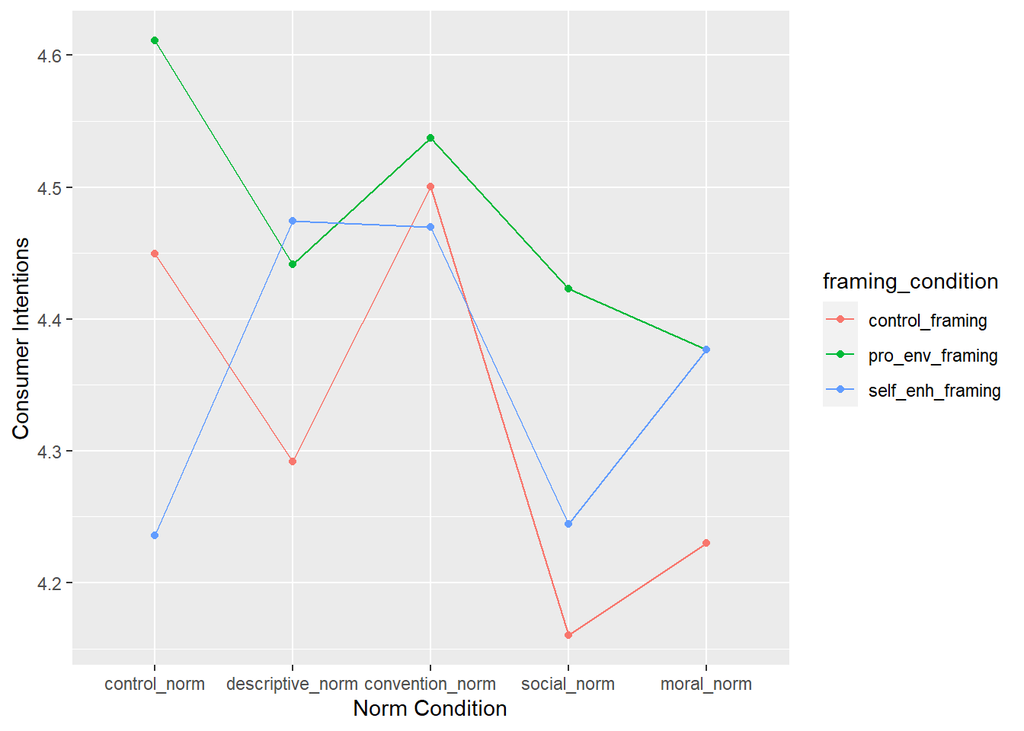

```r
emmip(mod_mice, framing_condition ~ norm_condition, CIs = FALSE, xlab = "Norm Condition", ylab = "Consumer Intentions")
```

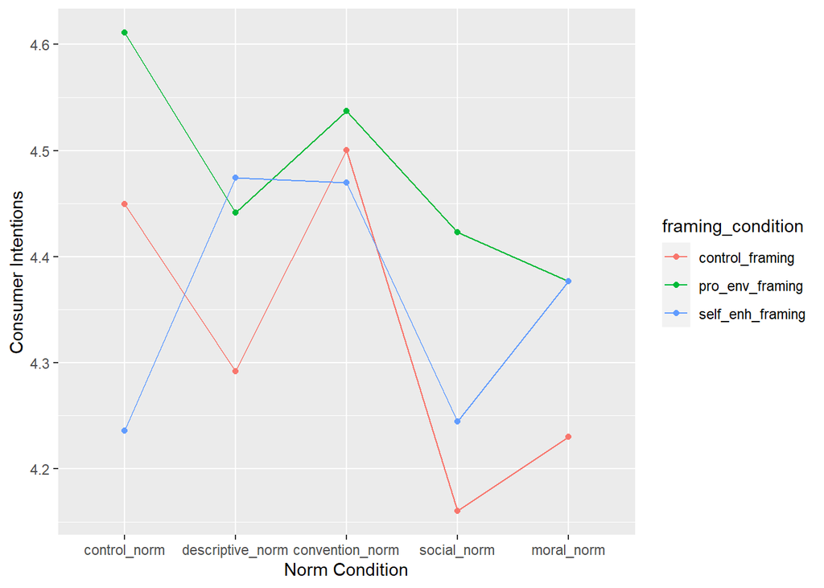

```r
emmip(mod_mice, framing_condition ~ norm_condition, CIs = FALSE, xlab = "Norm Condition", ylab = "Consumer Intentions")
```

# Exploratory Analyses

## Effect of framings across norm conditions

Comparing consumer intentions for each norm condition between each framing condition:

```r
# Control norm
chosen_values <- list(norm_condition = c("control_norm"), framing_condition = c("control_framing", "pro_env_framing", "self_enh_framing"))

control_norm_means <- emmeans(mod_mice, pairwise ~ norm_condition*framing_condition, at = chosen_values, adjust = "none")

control_norm_means$emmeans %>%
  knitr::kable(digits = 2)
```

| norm_condition | framing_condition | emmean | SE | df | lower.CL | upper.CL |
| --- | --- | --- | --- | --- | --- | --- |
| control_norm | control_framing | 4.45 | 0.12 | 1038 | 4.21 | 4.69 |
| control_norm | pro_env_framing | 4.61 | 0.13 | 1038 | 4.36 | 4.86 |
| control_norm | self_enh_framing | 4.24 | 0.13 | 1038 | 3.99 | 4.48 |

```r
control_norm_means$contrasts %>%
  knitr::kable(digits = c(NA,2,2,2,2,3))
```

| contrast | estimate | SE | df | t.ratio | p.value |
| --- | --- | --- | --- | --- | --- |
| control_norm control_framing - control_norm pro_env_framing | -0.16 | 0.18 | 1038 | -0.91 | 0.364 |
| control_norm control_framing - control_norm self_enh_framing | 0.21 | 0.18 | 1038 | 1.21 | 0.227 |
| control_norm pro_env_framing - control_norm self_enh_framing | 0.38 | 0.18 | 1038 | 2.08 | 0.037 |

```r
eff_size(control_norm_means, sigma = sigma_pool, edf = df_resid_pool) %>%
  knitr::kable(digits = 2)
```

| contrast | effect.size | SE | df | lower.CL | upper.CL |
| --- | --- | --- | --- | --- | --- |
| (control_norm control_framing - control_norm pro_env_framing) | -0.15 | 0.17 | 1038 | -0.48 | 0.18 |
| (control_norm control_framing - control_norm self_enh_framing) | 0.20 | 0.17 | 1038 | -0.12 | 0.52 |
| (control_norm pro_env_framing - control_norm self_enh_framing) | 0.35 | 0.17 | 1038 | 0.02 | 0.68 |

```r
# Descriptive norm
chosen_values <- list(norm_condition = c("descriptive_norm"), framing_condition = c("control_framing", "pro_env_framing", "self_enh_framing"))

descr_norm_means <- emmeans(mod_mice, pairwise ~ norm_condition*framing_condition, at = chosen_values, adjust = "none")

descr_norm_means$emmeans %>%
  knitr::kable(digits = 2)
```

| norm_condition | framing_condition | emmean | SE | df | lower.CL | upper.CL |
| --- | --- | --- | --- | --- | --- | --- |
| descriptive_norm | control_framing | 4.29 | 0.13 | 1038 | 4.03 | 4.55 |
| descriptive_norm | pro_env_framing | 4.44 | 0.13 | 1038 | 4.19 | 4.69 |
| descriptive_norm | self_enh_framing | 4.47 | 0.12 | 1038 | 4.24 | 4.71 |

```r
descr_norm_means$contrasts %>%
  knitr::kable(digits = c(NA,2,2,2,2,3))
```

| contrast | estimate | SE | df | t.ratio | p.value |
| --- | --- | --- | --- | --- | --- |
| descriptive_norm control_framing - descriptive_norm pro_env_framing | -0.15 | 0.18 | 1038 | -0.81 | 0.418 |
| descriptive_norm control_framing - descriptive_norm self_enh_framing | -0.18 | 0.18 | 1038 | -1.02 | 0.310 |
| descriptive_norm pro_env_framing - descriptive_norm self_enh_framing | -0.03 | 0.18 | 1038 | -0.18 | 0.854 |

```r
eff_size(descr_norm_means, sigma = sigma_pool, edf = df_resid_pool) %>%
  knitr::kable(digits = 2)
```

| contrast | effect.size | SE | df | lower.CL | upper.CL |
| --- | --- | --- | --- | --- | --- |
| (descriptive_norm control_framing - descriptive_norm pro_env_framing) | -0.14 | 0.17 | 1038 | -0.48 | 0.20 |
| (descriptive_norm control_framing - descriptive_norm self_enh_framing) | -0.17 | 0.17 | 1038 | -0.50 | 0.16 |
| (descriptive_norm pro_env_framing - descriptive_norm self_enh_framing) | -0.03 | 0.17 | 1038 | -0.36 | 0.29 |

```r
# Convention norm
chosen_values <- list(norm_condition = c("convention_norm"), framing_condition = c("control_framing", "pro_env_framing", "self_enh_framing"))

conv_norm_means <- emmeans(mod_mice, pairwise ~ norm_condition*framing_condition, at = chosen_values, adjust = "none")

conv_norm_means$emmeans %>%
  knitr::kable(digits = 2)
```

| norm_condition | framing_condition | emmean | SE | df | lower.CL | upper.CL |
| --- | --- | --- | --- | --- | --- | --- |
| convention_norm | control_framing | 4.50 | 0.14 | 1038 | 4.23 | 4.77 |
| convention_norm | pro_env_framing | 4.54 | 0.12 | 1038 | 4.30 | 4.77 |
| convention_norm | self_enh_framing | 4.47 | 0.13 | 1038 | 4.21 | 4.72 |

```r
conv_norm_means$contrasts %>%
  knitr::kable(digits = c(NA,2,2,2,2,3))
```

| contrast | estimate | SE | df | t.ratio | p.value |
| --- | --- | --- | --- | --- | --- |
| convention_norm control_framing - convention_norm pro_env_framing | -0.04 | 0.18 | 1038 | -0.20 | 0.838 |
| convention_norm control_framing - convention_norm self_enh_framing | 0.03 | 0.19 | 1038 | 0.16 | 0.872 |
| convention_norm pro_env_framing - convention_norm self_enh_framing | 0.07 | 0.18 | 1038 | 0.38 | 0.701 |

```r
eff_size(conv_norm_means, sigma = sigma_pool, edf = df_resid_pool) %>%
  knitr::kable(digits = 2)
```

| contrast | effect.size | SE | df | lower.CL | upper.CL |
| --- | --- | --- | --- | --- | --- |
| (convention_norm control_framing - convention_norm pro_env_framing) | -0.03 | 0.17 | 1038 | -0.37 | 0.30 |
| (convention_norm control_framing - convention_norm self_enh_framing) | 0.03 | 0.18 | 1038 | -0.32 | 0.38 |
| (convention_norm pro_env_framing - convention_norm self_enh_framing) | 0.06 | 0.16 | 1038 | -0.26 | 0.39 |

```r
# Social norm
chosen_values <- list(norm_condition = c("social_norm"), framing_condition = c("control_framing", "pro_env_framing", "self_enh_framing"))

soc_norm_means <- emmeans(mod_mice, pairwise ~ norm_condition*framing_condition, at = chosen_values, adjust = "none")

soc_norm_means$emmeans %>%
  knitr::kable(digits = 2)
```

| norm_condition | framing_condition | emmean | SE | df | lower.CL | upper.CL |
| --- | --- | --- | --- | --- | --- | --- |
| social_norm | control_framing | 4.16 | 0.12 | 1038 | 3.93 | 4.39 |
| social_norm | pro_env_framing | 4.42 | 0.13 | 1038 | 4.16 | 4.69 |
| social_norm | self_enh_framing | 4.24 | 0.14 | 1038 | 3.98 | 4.51 |

```r
soc_norm_means$contrasts %>%
  knitr::kable(digits = c(NA,2,2,2,2,3))
```

| contrast | estimate | SE | df | t.ratio | p.value |
| --- | --- | --- | --- | --- | --- |
| social_norm control_framing - social_norm pro_env_framing | -0.26 | 0.18 | 1038 | -1.48 | 0.138 |
| social_norm control_framing - social_norm self_enh_framing | -0.08 | 0.18 | 1038 | -0.47 | 0.637 |
| social_norm pro_env_framing - social_norm self_enh_framing | 0.18 | 0.19 | 1038 | 0.93 | 0.351 |

```r
eff_size(soc_norm_means, sigma = sigma_pool, edf = df_resid_pool) %>%
  knitr::kable(digits = 2)
```

| contrast | effect.size | SE | df | lower.CL | upper.CL |
| --- | --- | --- | --- | --- | --- |
| (social_norm control_framing - social_norm pro_env_framing) | -0.25 | 0.17 | 1038 | -0.57 | 0.08 |
| (social_norm control_framing - social_norm self_enh_framing) | -0.08 | 0.17 | 1038 | -0.41 | 0.25 |
| (social_norm pro_env_framing - social_norm self_enh_framing) | 0.17 | 0.18 | 1038 | -0.18 | 0.52 |

```r
# Moral norm
chosen_values <- list(norm_condition = c("moral_norm"), framing_condition = c("control_framing", "pro_env_framing", "self_enh_framing"))

moral_norm_means <- emmeans(mod_mice, pairwise ~ norm_condition*framing_condition, at = chosen_values, adjust = "none")

moral_norm_means$emmeans %>%
  knitr::kable(digits = 2)
```

| norm_condition | framing_condition | emmean | SE | df | lower.CL | upper.CL |
| --- | --- | --- | --- | --- | --- | --- |
| moral_norm | control_framing | 4.23 | 0.14 | 1038 | 3.95 | 4.51 |
| moral_norm | pro_env_framing | 4.38 | 0.12 | 1038 | 4.14 | 4.61 |
| moral_norm | self_enh_framing | 4.38 | 0.13 | 1038 | 4.12 | 4.63 |

```r
moral_norm_means$contrasts %>%
  knitr::kable(digits = c(NA,2,2,2,2,3))
```

| contrast | estimate | SE | df | t.ratio | p.value |
| --- | --- | --- | --- | --- | --- |
| moral_norm control_framing - moral_norm pro_env_framing | -0.15 | 0.19 | 1038 | -0.78 | 0.433 |
| moral_norm control_framing - moral_norm self_enh_framing | -0.15 | 0.19 | 1038 | -0.76 | 0.447 |
| moral_norm pro_env_framing - moral_norm self_enh_framing | 0.00 | 0.18 | 1038 | 0.00 | 0.999 |

```r
eff_size(moral_norm_means, sigma = sigma_pool, edf = df_resid_pool) %>%
  knitr::kable(digits = 2)
```

| contrast | effect.size | SE | df | lower.CL | upper.CL |
| --- | --- | --- | --- | --- | --- |
| (moral_norm control_framing - moral_norm pro_env_framing) | -0.14 | 0.18 | 1038 | -0.48 | 0.21 |
| (moral_norm control_framing - moral_norm self_enh_framing) | -0.14 | 0.18 | 1038 | -0.49 | 0.22 |
| (moral_norm pro_env_framing - moral_norm self_enh_framing) | 0.00 | 0.16 | 1038 | -0.32 | 0.32 |

## Gender Interactions

Gender X Norm

```r
emmeans(mod_mice, ~ norm_condition*Gender*framing_condition, adjust = "none")
```

```
##  norm_condition   Gender framing_condition emmean    SE   df lower.CL upper.CL
##  control_norm     Woman  control_framing     4.52 0.127 1038     4.27     4.77
##  descriptive_norm Woman  control_framing     4.37 0.135 1038     4.10     4.63
##  convention_norm  Woman  control_framing     4.57 0.141 1038     4.30     4.85
##  social_norm      Woman  control_framing     4.23 0.121 1038     4.00     4.47
##  moral_norm       Woman  control_framing     4.30 0.147 1038     4.02     4.59
##  control_norm     Man    control_framing     4.38 0.132 1038     4.12     4.63
##  descriptive_norm Man    control_framing     4.22 0.142 1038     3.94     4.50
##  convention_norm  Man    control_framing     4.43 0.144 1038     4.14     4.71
##  social_norm      Man    control_framing     4.09 0.125 1038     3.84     4.33
##  moral_norm       Man    control_framing     4.16 0.150 1038     3.86     4.45
##  control_norm     Woman  pro_env_framing     4.68 0.132 1038     4.43     4.94
##  descriptive_norm Woman  pro_env_framing     4.52 0.132 1038     4.26     4.78
##  convention_norm  Woman  pro_env_framing     4.61 0.121 1038     4.37     4.85
##  social_norm      Woman  pro_env_framing     4.50 0.135 1038     4.23     4.76
##  moral_norm       Woman  pro_env_framing     4.45 0.122 1038     4.21     4.69
##  control_norm     Man    pro_env_framing     4.54 0.136 1038     4.27     4.80
##  descriptive_norm Man    pro_env_framing     4.37 0.136 1038     4.10     4.63
##  convention_norm  Man    pro_env_framing     4.46 0.129 1038     4.21     4.72
##  social_norm      Man    pro_env_framing     4.35 0.144 1038     4.07     4.63
##  moral_norm       Man    pro_env_framing     4.30 0.132 1038     4.04     4.56
##  control_norm     Woman  self_enh_framing    4.31 0.129 1038     4.06     4.56
##  descriptive_norm Woman  self_enh_framing    4.55 0.125 1038     4.30     4.79
##  convention_norm  Woman  self_enh_framing    4.54 0.134 1038     4.28     4.81
##  social_norm      Woman  self_enh_framing    4.32 0.141 1038     4.04     4.60
##  moral_norm       Woman  self_enh_framing    4.45 0.132 1038     4.19     4.71
##  control_norm     Man    self_enh_framing    4.16 0.136 1038     3.89     4.43
##  descriptive_norm Man    self_enh_framing    4.40 0.130 1038     4.14     4.66
##  convention_norm  Man    self_enh_framing    4.40 0.137 1038     4.13     4.66
##  social_norm      Man    self_enh_framing    4.17 0.144 1038     3.89     4.45
##  moral_norm       Man    self_enh_framing    4.30 0.137 1038     4.03     4.57
##
## Confidence level used: 0.95
```

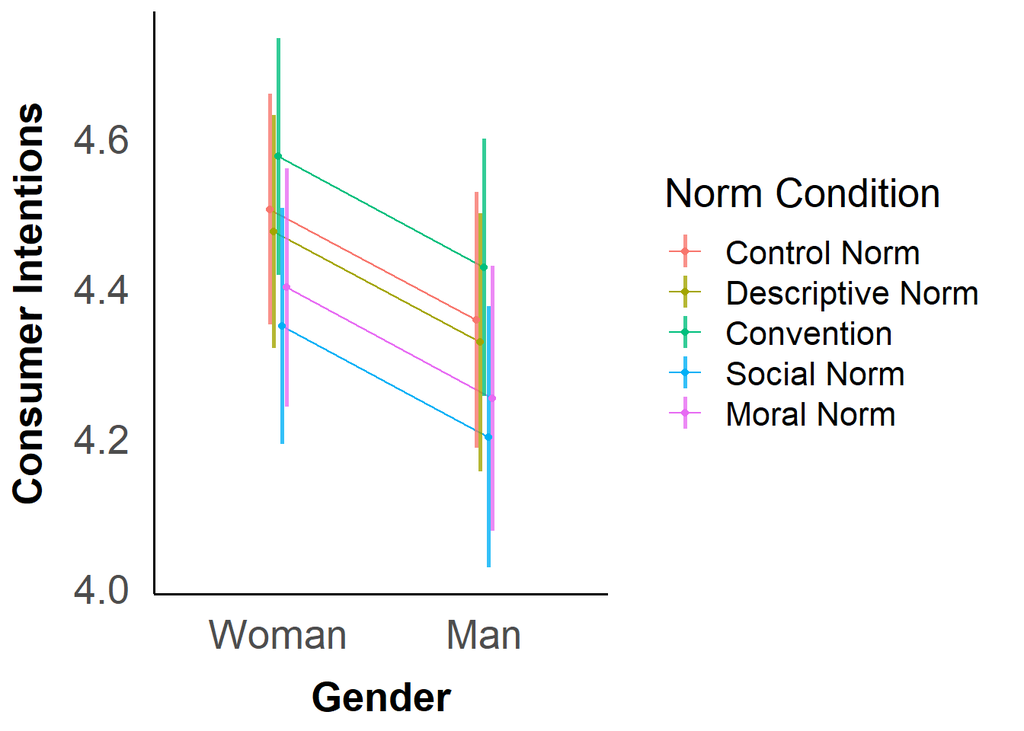

```r
emmip(mod_mice, norm_condition ~ Gender, CIs = TRUE, CIarg = list(lwd = 1, alpha = 0.8), xlab = "Gender", ylab = "Consumer Intentions") + scale_colour_discrete(name = "Norm Condition", breaks=c("control_norm","descriptive_norm", "convention_norm", "social_norm", "moral_norm"), labels=c("Control Norm", "Descriptive Norm", "Convention", "Social Norm", "Moral Norm")) +theme_apa() + text_settings
```

Gender X Framing

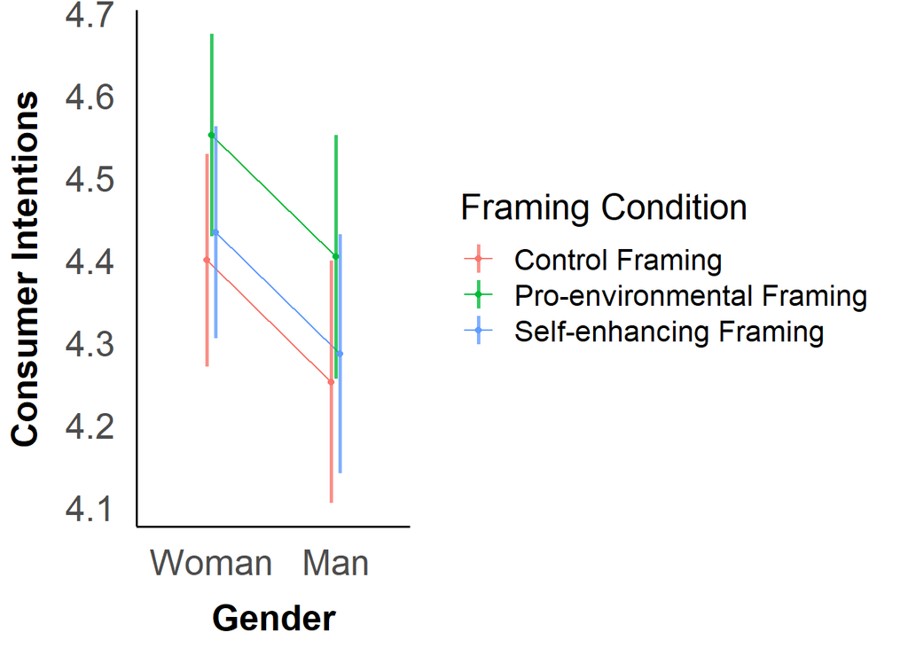

```r
emmip(mod_mice, framing_condition ~ Gender, CIs = TRUE, CIarg = list(lwd = 1, alpha = 0.8), xlab = "Gender", ylab = "Consumer Intentions") + scale_colour_discrete(name = "Framing Condition", breaks=c("control_framing","pro_env_framing","self_enh_framing"), labels=c("Control Framing", "Pro-environmental Framing", "Self-enhancing Framing")) +theme_apa() + text_settings
```

Gender X Norm X Framing

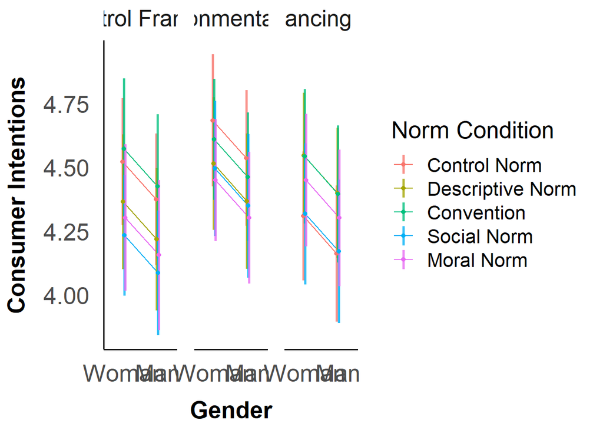

```r
emmip(mod_mice, norm_condition ~ Gender | framing_condition, CIs = TRUE, CIarg = list(lwd = 1, alpha = 0.8), xlab = "Gender", ylab = "Consumer Intentions") + scale_colour_discrete(name = "Norm Condition", breaks=c("control_norm","descriptive_norm", "convention_norm", "social_norm", "moral_norm"), labels=c("Control Norm", "Descriptive Norm", "Convention", "Social Norm", "Moral Norm")) + facet_wrap(~framing_condition, labeller = labeller(framing_condition = frame_labs)) +theme_apa() + text_settings
```

# Post-hoc Power Analysis

- Using final sample size (n = 1133) and a small effect size

from Cohen (1988):

f2 = R^2/(1 - R^2) R2 = f^2/(1 + f^2)

Small: f2 = .02, Small: R2 = .02

Model A (full model): PA = 95 Denominator df: n-PA = 1133-95 = 1038

Effects where numerator df: PA-PC = 4

- Main effect of norm
- Values X norm interactions
- Ingroup x norm interactions

```r
# If effect size were small and df_resid = 1038
pwr.f2.test(u = 4, # Numerator df (PA-PC)
            v = 1038, # Denominator df (n - PA)
            f2 = .02,
            sig.level = .05,
            power = NULL) # power = .97
```

```
##
##      Multiple regression power calculation
##
##               u = 4
##               v = 1038
##              f2 = 0.02
##       sig.level = 0.05
##           power = 0.9699383
```

Effects where numerator df: PA-PC = 2

- Main effect of framing
- Values X framing interactions
- Ingroup x framing interactions

```r
# If effect size were small and df_resid = 1038
pwr.f2.test(u = 2, # Numerator df (PA-PC)
            v = 1038, # Denominator df (n - PA)
            f2 = .02,
            sig.level = .05,
            power = NULL) # power = .99
```

```
##
##      Multiple regression power calculation
##
##               u = 2
##               v = 1038
##              f2 = 0.02
##       sig.level = 0.05
##           power = 0.9880386
```

Effects where numerator df: PA-PC = 8

- Norm x Framing interaction
- Values X framing x norm interactions
- Ingroup x framing x norm interactions

```r
# If effect size were small and df_resid = 1038
pwr.f2.test(u = 8, # Numerator df (PA-PC)
            v = 1038, # Denominator df (n - PA)
            f2 = .02,
            sig.level = .05,
            power = NULL) # power = .93
```

```
##
##      Multiple regression power calculation
##
##               u = 8
##               v = 1038
##              f2 = 0.02
##       sig.level = 0.05
##           power = 0.9270063
```

Effects where numerator df: PA-PC = 1

- Biospheric values
- Altruistic values
- Egoistic values
- Hedonic values
- Ingroup identification
- Self-deceptive enhancement
- Impression management
- Clothing interest
- Age
- Gender

```r
# If effect size were small and df_resid = 1038
pwr.f2.test(u = 1, # Numerator df (PA-PC)
            v = 1038, # Denominator df (n - PA)
            f2 = .02,
            sig.level = .05,
            power = NULL) # power = .995
```

```
##
##      Multiple regression power calculation
##
##               u = 1
##               v = 1038
##              f2 = 0.02
##       sig.level = 0.05
##           power = 0.9952913
```

Checking p-values from Pooled ANOVA table

```r
# p-value for biospheric values
pf(60.76, df1 = 1, df2 = 182541.21, lower.tail = FALSE)
```

```
## [1] 0.000000000000006481222
```

```r
# p-value for framing condition
pf(1.94, df1 = 2, df2 = 277911.15, lower.tail = FALSE)
```

```
## [1] 0.1437059
```

Q: Which of the pooled ANOVA effects would be significant if the non-adjusted denominator df, 1038, were used?

df1 = 1:

- F-critical value when df1 = 1 & df2 = 1038: Fcv = 3.8504
- F-critical value when df1 = 1 & df2 = 9999: Fcv = 3.8424

df1 = 2:

- F-critical value when df1 = 2 & df2 = 1038: Fcv = 3.0044
- F-critical value when df1 = 2 & df2 = 9999: Fcv = 2.9966

df1 = 4:

- F-critical value when df1 = 4 & df2 = 1038: Fcv = 2.3805
- F-critical value when df1 = 4 & df2 = 9999: Fcv = 2.3728

df1 = 8:

- F-critical value when df1 = 8 & df2 = 1038: Fcv = 1.9473
- F-critical value when df1 = 8 & df2 = 9999: Fcv = 1.9393